# Práctica Markowitz y Factor común

Azael Carrillo Cabrera

Profesor: Dr. Gustavo Cabrera González

```r
library(ggplot2)
library(ggthemes)
library(scales)
library(reshape2)
library(dplyr)
library(readxl)
library(knitr)
library(kableExtra)
```

## Parte Uno: Teorema de Markowitz

### Extraemos los datos y los preparamos:

```r
dataEmis <- read_excel(path = "HM_data_emisoras.xlsx",
                               sheet = "data_emisoras",
                               col_types = c("date",
                                             "numeric", "numeric", "numeric",
                                             "numeric", "numeric", "numeric",
                                             "numeric", "numeric", "numeric",
                                             "numeric", "numeric", "numeric",
                                             "numeric", "numeric", "numeric",
                                             "numeric", "numeric", "numeric",
                                             "numeric", "numeric", "numeric",
                                             "numeric", "numeric", "numeric",
                                             "numeric", "numeric", "numeric"),
                               na = "na")
##Borramos los registros que tienen NA en su fila
dataEmis <- dataEmis[complete.cases(dataEmis),]
kable(head(dataEmis, 50) ,escape = F) %>%
  kable_styling("hover", full_width = F) %>%
  column_spec(1, width = "2cm") %>%
  scroll_box(width = "100%", height = "300px")
```

| Pricing date | Alfa S.A.B de C.V (BMV:ALFA A) - Share Pricing | Arca Continental, S. A. B. de C. V. (BMV:AC *) - Share Pricing | Alsea, S.A.B. De C.V. (BMV:ALSEA *) - Share Pricing | America Movil S.A.B. de C.V. (BMV:AMX L) - Share Pricing | Grupo Aeroportuario del Sureste, SAB de CV (BMV:ASUR B) - Share Pricing | Grupo Bimbo, S.A.B. de C.V. (BMV:BIMBO A) - Share Pricing | CEMEX, S.A.B. de C.V. (BMV:CEMEX CPO) - Share Pricing | Controladora Comercial Mexicana SAB DE CV (BMV:COMERCI UBC) - Share Pricing | Grupo Elektra, S.A.B. de C.V. (BMV:ELEKTRA *) - Share Pricing | Fomento Económico Mexicano, S.A.B de C.V (BMV:FEMSA UBD) - Share Pricing | Grupo Aeroportuario del Pacifico S.A.B. de CV (BMV:GAP B) - Share Pricing | Grupo Carso, S.A.B. de C.V. (BMV:GCARSO A1) - Share Pricing | Grupo Financiero Inbursa, S.A.B. de C.V. (BMV:GFINBUR O) - Share Pricing | Grupo Financiero Banorte, S.A.B. de C.V. (BMV:GFNORTE O) - Share Pricing | Grupo México S.A.B. de C.V. (BMV:GMEXICO B) - Share Pricing | Gruma S.A.B. de CV (BMV:GRUMA B) - Share Pricing | Empresas ICA, S.A.B. de C.V. (BMV:ICA *) - Share Pricing | Industrias CH, SAB de CV (BMV:ICH B) - Share Pricing | Kimberly - Clark de Mexico S.A.B. de C.V. (BMV:KIMBER A) - Share Pricing | Coca-Cola FEMSA S.A.B de C.V. (NYSE:KOF) - Share Pricing | El Puerto de Liverpool, SAB de CV (BMV:LIVEPOL C-1) - Share Pricing | Mexichem, S.A.B. de C.V. (BMV:MEXCHEM *) - Share Pricing | Industrias Penoles S.A.B. DE CV (BMV:PE&OLES *) - Share Pricing | Promotora y Operadora de Infraestructura SAB de CV (BMV:PINFRA *) - Share Pricing | Grupo Financiero Santander Mexico, S.A.B. de C.V. (BMV:SANMEX B) - Share Pricing | Grupo Televisa, S.A.B. (BMV:TLEVISA CPO) - Share Pricing | Wal-Mart de Mexico SAB De CV (BMV:WALMEX *) - Share Pricing |
| --- | --- | --- | --- | --- | --- | --- | --- | --- | --- | --- | --- | --- | --- | --- | --- | --- | --- | --- | --- | --- | --- | --- | --- | --- | --- | --- | --- |
| 2006-03-09 | 5.368 | 23.97 | 8.753044 | 8.940 | 35.18 | 8.8250 | 24.18438 | 17.73 | 117.80 | 29.88667 | 31.62 | 25.35 | 8.005 | 23.61 | 8.743602 | 32.39 | 30.93 | 22.80 | 11.77000 | 30.22 | 25.05 | 4.633287 | 74.21 | 7.00 | 10.00 | 41.10 | 14.105 |
| 2006-03-10 | 5.446 | 23.17 | 8.808704 | 8.900 | 35.10 | 8.8675 | 24.27937 | 18.35 | 117.57 | 30.33333 | 31.60 | 25.44 | 8.000 | 23.56 | 9.032232 | 32.20 | 31.49 | 23.31 | 11.66333 | 30.40 | 25.05 | 4.683286 | 74.38 | 6.90 | 10.00 | 41.31 | 14.395 |
| 2006-03-13 | 5.556 | 22.64 | 8.820804 | 9.145 | 35.52 | 8.9450 | 24.57574 | 18.69 | 118.40 | 30.15333 | 32.51 | 25.51 | 8.340 | 24.07 | 9.047919 | 32.70 | 31.43 | 24.00 | 11.78667 | 30.35 | 25.05 | 4.716619 | 74.98 | 6.83 | 10.00 | 42.27 | 14.540 |
| 2006-03-14 | 5.653 | 22.97 | 8.820804 | 9.320 | 35.16 | 9.0375 | 24.65173 | 18.80 | 120.00 | 30.07666 | 32.56 | 26.02 | 8.300 | 24.43 | 9.245567 | 33.11 | 31.57 | 23.90 | 11.96333 | 30.73 | 25.05 | 4.716619 | 75.75 | 6.90 | 10.00 | 42.24 | 14.650 |
| 2006-03-15 | 5.618 | 23.00 | 8.832903 | 9.295 | 35.26 | 8.9975 | 25.68902 | 19.08 | 119.99 | 31.80667 | 34.03 | 25.72 | 8.085 | 24.51 | 9.204783 | 33.19 | 31.78 | 23.80 | 11.73667 | 31.13 | 25.10 | 4.716619 | 74.39 | 6.85 | 10.00 | 42.00 | 14.605 |
| 2006-03-16 | 5.616 | 23.81 | 8.736105 | 9.310 | 35.60 | 9.1250 | 26.55913 | 19.10 | 119.00 | 32.31667 | 34.90 | 25.91 | 8.235 | 24.88 | 9.211058 | 33.46 | 32.48 | 23.59 | 11.85000 | 30.96 | 25.10 | 4.729952 | 74.00 | 6.89 | 10.00 | 41.71 | 14.850 |
| 2006-03-17 | 5.810 | 23.79 | 8.711905 | 9.490 | 35.21 | 9.3600 | 26.55532 | 18.88 | 115.01 | 32.61000 | 35.00 | 26.40 | 8.015 | 24.67 | 9.628316 | 33.81 | 31.90 | 23.43 | 11.95333 | 30.85 | 25.10 | 4.729952 | 74.51 | 6.82 | 10.00 | 41.77 | 15.005 |
| 2006-03-20 | 6.000 | 23.70 | 8.711905 | 9.625 | 35.30 | 9.3800 | 27.00748 | 18.98 | 115.00 | 33.07000 | 35.79 | 26.44 | 8.280 | 24.78 | 9.662825 | 33.47 | 32.47 | 24.30 | 12.16667 | 31.12 | 25.10 | 4.729952 | 75.50 | 6.80 | 9.45 | 42.05 | 15.085 |
| 2006-03-22 | 6.111 | 24.00 | 8.711905 | 9.530 | 35.60 | 9.3300 | 27.11387 | 18.76 | 114.40 | 32.44667 | 36.88 | 26.12 | 8.230 | 25.04 | 9.709885 | 33.17 | 32.63 | 24.71 | 12.04000 | 30.95 | 25.10 | 4.766619 | 77.50 | 6.79 | 9.45 | 41.97 | 15.210 |
| 2006-03-23 | 6.008 | 23.85 | 8.953902 | 9.380 | 35.99 | 9.1350 | 26.76810 | 18.02 | 110.39 | 32.53667 | 36.70 | 25.33 | 8.135 | 24.19 | 9.295764 | 32.50 | 31.93 | 25.10 | 11.85000 | 30.72 | 25.10 | 4.699953 | 77.16 | 6.77 | 9.45 | 41.33 | 14.810 |
| 2006-03-24 | 6.032 | 23.95 | 8.953902 | 9.405 | 35.90 | 9.2225 | 26.95048 | 18.35 | 110.39 | 32.54333 | 35.31 | 25.51 | 8.175 | 24.90 | 9.211058 | 33.00 | 32.25 | 25.50 | 12.09667 | 30.50 | 25.10 | 4.666620 | 77.33 | 6.70 | 9.50 | 41.56 | 14.825 |
| 2006-03-27 | 6.102 | 23.97 | 8.956323 | 9.340 | 36.00 | 8.9300 | 27.01888 | 18.40 | 109.50 | 32.90000 | 33.80 | 25.13 | 8.140 | 24.63 | 9.314588 | 32.99 | 31.30 | 25.64 | 12.17333 | 30.49 | 25.10 | 4.733286 | 79.12 | 6.60 | 9.05 | 41.93 | 14.545 |
| 2006-03-28 | 5.992 | 23.70 | 9.050701 | 9.230 | 35.95 | 8.8500 | 26.10697 | 18.78 | 109.00 | 33.55333 | 35.45 | 24.98 | 7.785 | 23.94 | 9.220470 | 32.29 | 30.81 | 25.48 | 12.24000 | 31.75 | 25.10 | 4.666620 | 79.30 | 6.50 | 9.05 | 42.58 | 14.170 |
| 2006-03-29 | 5.994 | 23.84 | 9.087001 | 9.245 | 36.85 | 8.8975 | 26.54393 | 18.72 | 109.11 | 33.57333 | 35.90 | 25.12 | 8.225 | 24.42 | 9.455766 | 32.14 | 31.99 | 26.46 | 12.39667 | 32.34 | 25.10 | 4.733286 | 82.66 | 6.51 | 9.05 | 43.48 | 14.355 |
| 2006-03-30 | 6.079 | 24.30 | 9.162020 | 9.250 | 36.65 | 8.9750 | 26.83270 | 18.80 | 108.81 | 33.33333 | 34.99 | 25.32 | 8.065 | 24.94 | 9.650276 | 31.83 | 33.04 | 26.94 | 12.43333 | 32.70 | 25.10 | 4.699953 | 87.00 | 6.60 | 9.05 | 43.22 | 14.410 |
| 2006-03-31 | 6.211 | 25.00 | 9.099100 | 9.295 | 36.51 | 8.9325 | 26.93908 | 18.60 | 110.99 | 33.15000 | 34.75 | 24.90 | 8.200 | 25.89 | 9.700474 | 32.17 | 33.49 | 27.72 | 12.41667 | 33.20 | 24.50 | 4.699953 | 85.81 | 6.60 | 9.05 | 43.16 | 14.400 |
| 2006-04-03 | 6.283 | 25.60 | 9.135400 | 9.540 | 37.11 | 9.0725 | 27.13666 | 18.75 | 115.33 | 33.71667 | 34.49 | 25.85 | 8.250 | 26.40 | 10.039299 | 32.56 | 33.57 | 27.45 | 12.52333 | 33.66 | 24.50 | 4.599954 | 89.84 | 6.70 | 9.00 | 43.16 | 14.815 |
| 2006-04-04 | 6.304 | 26.48 | 9.123300 | 9.500 | 37.25 | 9.3625 | 27.76359 | 18.95 | 118.00 | 33.94333 | 34.19 | 25.92 | 8.200 | 26.01 | 10.334204 | 33.00 | 33.47 | 27.50 | 12.54000 | 33.59 | 24.50 | 4.616620 | 90.00 | 6.75 | 9.00 | 43.30 | 14.995 |
| 2006-04-05 | 6.025 | 26.49 | 9.169280 | 9.565 | 38.51 | 9.1625 | 28.32213 | 18.88 | 118.00 | 33.83000 | 34.34 | 25.90 | 8.265 | 25.59 | 10.663619 | 33.86 | 33.77 | 27.72 | 12.53667 | 33.49 | 24.50 | 4.599954 | 90.00 | 7.00 | 9.00 | 44.72 | 15.055 |
| 2006-04-06 | 5.989 | 26.54 | 9.123300 | 9.485 | 38.80 | 9.1875 | 28.69829 | 18.54 | 112.49 | 33.40667 | 34.38 | 25.20 | 8.280 | 25.59 | 10.807934 | 33.06 | 33.01 | 28.25 | 12.70667 | 33.42 | 24.50 | 4.649953 | 90.50 | 7.00 | 8.00 | 46.20 | 14.930 |
| 2006-04-07 | 5.925 | 26.54 | 9.123300 | 9.155 | 39.02 | 9.0500 | 28.38673 | 18.00 | 112.90 | 32.61667 | 34.96 | 24.97 | 8.225 | 25.22 | 10.509892 | 32.01 | 32.56 | 27.76 | 12.66333 | 32.66 | 24.50 | 4.616620 | 90.20 | 7.06 | 7.90 | 45.50 | 14.665 |
| 2006-04-10 | 5.907 | 26.50 | 9.135400 | 9.170 | 39.35 | 8.9900 | 28.62990 | 17.70 | 112.90 | 32.81333 | 34.45 | 24.80 | 8.325 | 25.15 | 10.619696 | 32.40 | 32.91 | 28.00 | 12.43333 | 33.03 | 24.50 | 4.616620 | 90.00 | 7.15 | 9.09 | 45.60 | 15.045 |
| 2006-04-11 | 5.865 | 26.95 | 9.195899 | 9.130 | 39.06 | 9.0050 | 27.97637 | 18.20 | 112.93 | 32.13333 | 32.81 | 25.49 | 8.490 | 25.09 | 10.516167 | 31.73 | 32.34 | 28.10 | 12.37000 | 33.00 | 24.50 | 4.613287 | 90.60 | 7.10 | 10.00 | 44.46 | 15.195 |
| 2006-04-12 | 5.845 | 26.87 | 9.341098 | 9.130 | 38.86 | 9.0400 | 27.63441 | 18.20 | 113.97 | 32.54333 | 32.36 | 25.10 | 8.235 | 25.89 | 10.669894 | 31.69 | 32.15 | 28.02 | 12.50000 | 32.86 | 24.45 | 4.583287 | 91.12 | 7.11 | 10.00 | 44.04 | 15.015 |
| 2006-04-17 | 5.894 | 26.74 | 9.483876 | 9.485 | 41.96 | 9.1925 | 27.68380 | 18.80 | 115.00 | 32.93000 | 32.45 | 25.32 | 8.285 | 26.74 | 11.168721 | 33.49 | 32.16 | 29.48 | 12.71667 | 32.23 | 24.45 | 4.549954 | 94.00 | 7.30 | 10.00 | 44.19 | 14.955 |
| 2006-04-18 | 5.910 | 27.33 | 9.679895 | 9.475 | 40.50 | 9.0050 | 28.31833 | 18.80 | 113.10 | 32.63000 | 32.82 | 25.53 | 8.295 | 28.31 | 11.846374 | 33.87 | 32.54 | 30.97 | 13.03667 | 32.83 | 24.45 | 4.666620 | 97.04 | 7.45 | 10.00 | 44.82 | 14.805 |
| 2006-04-19 | 5.919 | 27.00 | 9.776694 | 9.450 | 40.68 | 8.8900 | 28.64890 | 18.95 | 113.00 | 32.43667 | 33.33 | 25.60 | 8.340 | 29.05 | 11.909119 | 33.75 | 32.98 | 30.34 | 13.08333 | 32.70 | 24.45 | 4.719952 | 98.82 | 7.49 | 10.00 | 45.62 | 15.210 |
| 2006-04-20 | 5.905 | 27.47 | 9.825093 | 9.540 | 40.30 | 8.8875 | 27.94218 | 18.75 | 112.11 | 32.55333 | 33.50 | 25.60 | 8.535 | 29.45 | 11.394606 | 34.12 | 33.01 | 30.07 | 13.10000 | 32.83 | 24.45 | 4.766619 | 94.06 | 7.50 | 10.00 | 47.08 | 15.830 |
| 2006-04-21 | 5.930 | 28.40 | 9.919471 | 9.745 | 40.31 | 8.9025 | 27.90038 | 18.86 | 110.67 | 32.91667 | 34.02 | 26.61 | 8.545 | 29.17 | 11.981276 | 33.86 | 33.07 | 31.65 | 13.08000 | 33.61 | 24.45 | 4.816618 | 97.72 | 7.55 | 10.00 | 48.37 | 15.750 |
| 2006-04-24 | 5.820 | 28.24 | 10.163889 | 9.805 | 40.27 | 8.8500 | 27.54322 | 18.68 | 109.77 | 33.07666 | 34.59 | 26.87 | 8.750 | 28.31 | 11.764805 | 34.41 | 33.31 | 32.15 | 13.01667 | 33.35 | 24.45 | 4.736619 | 96.03 | 7.45 | 10.00 | 48.25 | 15.955 |
| 2006-04-25 | 5.617 | 28.12 | 10.672083 | 9.920 | 40.30 | 8.9000 | 28.08276 | 18.26 | 114.00 | 33.04000 | 34.79 | 26.86 | 8.750 | 28.19 | 11.730294 | 34.31 | 33.92 | 31.80 | 13.12333 | 32.84 | 24.45 | 4.739952 | 96.90 | 7.64 | 10.00 | 47.41 | 16.215 |
| 2006-04-26 | 5.633 | 28.29 | 11.603773 | 10.170 | 41.85 | 8.9575 | 28.57291 | 18.51 | 115.15 | 33.86667 | 35.24 | 26.33 | 8.675 | 28.79 | 11.645587 | 34.17 | 34.20 | 32.00 | 13.12333 | 33.00 | 24.45 | 4.833285 | 97.88 | 8.19 | 10.00 | 47.83 | 16.115 |
| 2006-04-27 | 5.575 | 27.95 | 11.603773 | 10.065 | 42.50 | 8.7125 | 28.04476 | 18.78 | 116.66 | 33.62000 | 37.87 | 26.07 | 8.715 | 29.05 | 11.435390 | 34.01 | 34.01 | 30.50 | 13.00667 | 32.77 | 24.45 | 4.899951 | 97.00 | 8.16 | 10.00 | 47.07 | 15.800 |
| 2006-04-28 | 5.567 | 28.94 | 11.373876 | 10.225 | 42.82 | 8.6550 | 28.42092 | 18.80 | 119.37 | 34.17000 | 36.71 | 26.19 | 8.765 | 28.90 | 12.163240 | 34.68 | 34.48 | 30.40 | 13.02000 | 32.20 | 24.00 | 5.049949 | 99.92 | 8.16 | 10.00 | 47.04 | 15.775 |
| 2006-05-02 | 5.587 | 28.24 | 11.615873 | 10.485 | 42.36 | 8.7375 | 29.16564 | 19.24 | 120.56 | 35.36000 | 39.43 | 26.87 | 8.495 | 30.08 | 12.172651 | 33.99 | 35.65 | 30.96 | 13.48667 | 32.62 | 24.00 | 5.166615 | 103.99 | 8.59 | 10.00 | 48.77 | 16.190 |
| 2006-05-03 | 5.548 | 28.94 | 11.690893 | 10.710 | 42.77 | 8.6950 | 29.03646 | 19.81 | 120.72 | 34.89667 | 40.25 | 26.77 | 8.550 | 30.39 | 11.877746 | 33.49 | 36.38 | 30.85 | 13.46333 | 32.68 | 24.00 | 5.523278 | 105.00 | 9.03 | 10.00 | 48.72 | 16.245 |
| 2006-05-04 | 5.738 | 29.32 | 12.293466 | 10.810 | 42.39 | 8.7875 | 29.34802 | 20.45 | 127.30 | 35.03333 | 39.01 | 26.79 | 8.420 | 30.43 | 12.135003 | 33.05 | 36.53 | 30.88 | 13.44333 | 32.99 | 23.90 | 5.466612 | 105.16 | 8.99 | 10.10 | 48.41 | 16.255 |
| 2006-05-05 | 5.721 | 29.40 | 12.099868 | 10.720 | 41.71 | 8.7800 | 29.13145 | 20.65 | 134.50 | 34.99000 | 39.32 | 26.42 | 8.425 | 31.54 | 12.298142 | 32.34 | 37.00 | 31.05 | 13.83333 | 33.82 | 23.90 | 5.566611 | 104.50 | 8.80 | 11.00 | 48.99 | 15.880 |
| 2006-05-08 | 5.693 | 30.68 | 12.097448 | 11.005 | 41.25 | 8.7725 | 29.79638 | 20.40 | 135.75 | 35.17000 | 40.50 | 26.40 | 8.525 | 31.65 | 12.464418 | 32.30 | 36.64 | 31.44 | 13.67333 | 34.44 | 24.30 | 5.533278 | 104.00 | 9.15 | 11.00 | 49.72 | 16.355 |
| 2006-05-09 | 5.690 | 30.79 | 12.099868 | 11.135 | 41.08 | 8.7625 | 29.58740 | 20.70 | 140.00 | 35.19000 | 41.27 | 26.82 | 8.565 | 31.22 | 12.385986 | 31.79 | 37.98 | 31.56 | 13.47000 | 33.74 | 24.30 | 5.516611 | 104.24 | 9.40 | 11.00 | 49.56 | 17.080 |
| 2006-05-10 | 5.730 | 30.75 | 12.148267 | 11.080 | 40.37 | 8.8000 | 29.41642 | 20.55 | 140.00 | 34.96000 | 41.35 | 26.47 | 8.475 | 30.32 | 12.411084 | 31.63 | 40.16 | 32.19 | 13.47667 | 34.02 | 24.50 | 5.533278 | 103.50 | 10.01 | 12.00 | 49.48 | 17.260 |
| 2006-05-11 | 5.665 | 30.80 | 12.099868 | 10.720 | 40.76 | 8.7550 | 29.65579 | 20.44 | 140.23 | 34.33333 | 40.53 | 26.05 | 8.580 | 30.35 | 12.345202 | 31.56 | 39.46 | 31.61 | 13.32333 | 32.95 | 24.70 | 5.533278 | 103.58 | 10.18 | 12.00 | 48.16 | 16.835 |
| 2006-05-12 | 5.634 | 29.95 | 11.736872 | 10.540 | 40.91 | 8.6575 | 28.95287 | 20.33 | 137.03 | 34.48667 | 39.66 | 25.68 | 8.390 | 29.57 | 12.175788 | 31.34 | 38.44 | 30.94 | 13.18667 | 33.08 | 24.70 | 5.466612 | 101.74 | 10.65 | 12.00 | 48.30 | 16.840 |
| 2006-05-15 | 5.586 | 29.50 | 11.131879 | 10.260 | 41.72 | 8.5750 | 28.26134 | 20.32 | 131.19 | 34.28333 | 39.84 | 25.37 | 8.250 | 29.26 | 11.372644 | 31.27 | 36.63 | 30.45 | 13.33000 | 32.87 | 24.90 | 5.416612 | 97.09 | 10.30 | 12.00 | 47.04 | 16.375 |
| 2006-05-16 | 5.601 | 29.08 | 10.826961 | 10.405 | 41.30 | 8.6775 | 27.68380 | 20.25 | 131.56 | 34.63667 | 39.56 | 25.48 | 8.395 | 28.82 | 11.607940 | 30.28 | 37.50 | 30.53 | 13.33333 | 33.45 | 25.00 | 5.433279 | 98.97 | 10.45 | 12.00 | 46.31 | 16.610 |
| 2006-05-17 | 5.531 | 28.57 | 10.650304 | 10.155 | 39.70 | 8.6050 | 26.83649 | 20.10 | 132.00 | 34.30333 | 38.36 | 25.56 | 8.315 | 26.86 | 10.974209 | 28.63 | 36.20 | 30.61 | 12.72667 | 32.32 | 24.80 | 5.333280 | 92.75 | 10.24 | 12.00 | 44.94 | 15.935 |
| 2006-05-18 | 5.574 | 28.90 | 10.882621 | 10.130 | 39.86 | 8.6350 | 26.41094 | 20.02 | 134.00 | 33.70333 | 37.60 | 25.92 | 8.530 | 27.85 | 10.845581 | 29.11 | 35.83 | 30.68 | 12.75333 | 31.66 | 24.60 | 5.399946 | 89.41 | 10.20 | 11.40 | 44.39 | 15.895 |
| 2006-05-19 | 5.549 | 28.00 | 10.647884 | 10.170 | 40.21 | 8.6375 | 26.50593 | 20.10 | 133.07 | 33.63333 | 37.66 | 26.14 | 8.525 | 28.00 | 10.400087 | 28.71 | 36.50 | 30.11 | 12.62667 | 31.25 | 24.60 | 5.399946 | 89.43 | 10.15 | 11.40 | 44.43 | 16.140 |
| 2006-05-22 | 5.365 | 28.47 | 10.393787 | 9.550 | 40.17 | 8.5125 | 25.50284 | 19.41 | 129.48 | 32.00000 | 36.08 | 25.94 | 8.235 | 26.15 | 9.976554 | 26.61 | 34.23 | 28.95 | 12.52667 | 30.72 | 24.60 | 5.266614 | 83.89 | 9.61 | 11.40 | 43.12 | 15.780 |
| 2006-05-23 | 5.359 | 28.21 | 10.417987 | 9.330 | 40.98 | 8.4400 | 25.37365 | 19.40 | 128.95 | 32.75667 | 36.76 | 25.80 | 8.150 | 25.86 | 10.139692 | 28.01 | 33.38 | 28.54 | 13.23333 | 30.50 | 24.60 | 5.266614 | 78.05 | 9.70 | 11.40 | 42.54 | 15.310 |

### 1) Tomar tasas de crecimieno diario

```r
creci <- function(x){
  100*(x-lag(x))/lag(x)
}
emisCre <- data.frame(apply(dataEmis[,-1], 2, creci))
emisCre$date <- dataEmis$`Pricing date`
emisCre <- emisCre[,c(28, 1:27)]
emisCre <- emisCre[complete.cases(emisCre),]
attributes(emisCre)$names <- attributes(dataEmis)$names
##Alterna compacta: emisCre <- data.frame(apply(dataEmis[,-1], 2, function(x) 100*(x-lag(x))/lag(x)))
kable(head(emisCre, 50) ,escape = F) %>%
  kable_styling("hover", full_width = F) %>%
  column_spec(1, width = "2cm") %>%
  scroll_box(width = "100%", height = "300px")
```

|  | Pricing date | Alfa S.A.B de C.V (BMV:ALFA A) - Share Pricing | Arca Continental, S. A. B. de C. V. (BMV:AC *) - Share Pricing | Alsea, S.A.B. De C.V. (BMV:ALSEA *) - Share Pricing | America Movil S.A.B. de C.V. (BMV:AMX L) - Share Pricing | Grupo Aeroportuario del Sureste, SAB de CV (BMV:ASUR B) - Share Pricing | Grupo Bimbo, S.A.B. de C.V. (BMV:BIMBO A) - Share Pricing | CEMEX, S.A.B. de C.V. (BMV:CEMEX CPO) - Share Pricing | Controladora Comercial Mexicana SAB DE CV (BMV:COMERCI UBC) - Share Pricing | Grupo Elektra, S.A.B. de C.V. (BMV:ELEKTRA *) - Share Pricing | Fomento Económico Mexicano, S.A.B de C.V (BMV:FEMSA UBD) - Share Pricing | Grupo Aeroportuario del Pacifico S.A.B. de CV (BMV:GAP B) - Share Pricing | Grupo Carso, S.A.B. de C.V. (BMV:GCARSO A1) - Share Pricing | Grupo Financiero Inbursa, S.A.B. de C.V. (BMV:GFINBUR O) - Share Pricing | Grupo Financiero Banorte, S.A.B. de C.V. (BMV:GFNORTE O) - Share Pricing | Grupo México S.A.B. de C.V. (BMV:GMEXICO B) - Share Pricing | Gruma S.A.B. de CV (BMV:GRUMA B) - Share Pricing | Empresas ICA, S.A.B. de C.V. (BMV:ICA *) - Share Pricing | Industrias CH, SAB de CV (BMV:ICH B) - Share Pricing | Kimberly - Clark de Mexico S.A.B. de C.V. (BMV:KIMBER A) - Share Pricing | Coca-Cola FEMSA S.A.B de C.V. (NYSE:KOF) - Share Pricing | El Puerto de Liverpool, SAB de CV (BMV:LIVEPOL C-1) - Share Pricing | Mexichem, S.A.B. de C.V. (BMV:MEXCHEM *) - Share Pricing | Industrias Penoles S.A.B. DE CV (BMV:PE&OLES *) - Share Pricing | Promotora y Operadora de Infraestructura SAB de CV (BMV:PINFRA *) - Share Pricing | Grupo Financiero Santander Mexico, S.A.B. de C.V. (BMV:SANMEX B) - Share Pricing | Grupo Televisa, S.A.B. (BMV:TLEVISA CPO) - Share Pricing | Wal-Mart de Mexico SAB De CV (BMV:WALMEX *) - Share Pricing |
| --- | --- | --- | --- | --- | --- | --- | --- | --- | --- | --- | --- | --- | --- | --- | --- | --- | --- | --- | --- | --- | --- | --- | --- | --- | --- | --- | --- | --- |
| 2 | 2006-03-10 | 1.4530551 | -3.3375052 | 0.6358931 | -0.4474273 | -0.2274019 | 0.4815864 | 0.3927783 | 3.4968979 | -0.1952462 | 1.4945361 | -0.0632511 | 0.3550296 | -0.0624610 | -0.2117747 | 3.3010423 | -0.5866008 | 1.8105399 | 2.2368421 | -0.9062618 | 0.5956320 | 0.0000000 | 1.0791259 | 0.2290796 | -1.4285714 | 0.0000000 | 0.5109489 | 2.0560085 |
| 3 | 2006-03-13 | 2.0198311 | -2.2874407 | 0.1373641 | 2.7528090 | 1.1965812 | 0.8739780 | 1.2206535 | 1.8528610 | 0.7059624 | -0.5934099 | 2.8797468 | 0.2751572 | 4.2500000 | 2.1646859 | 0.1736780 | 1.5527950 | -0.1905367 | 2.9601030 | 1.0574508 | -0.1644737 | 0.0000000 | 0.7117438 | 0.8066685 | -1.0144928 | 0.0000000 | 2.3238925 | 1.0072942 |
| 4 | 2006-03-14 | 1.7458603 | 1.4575972 | 0.0000000 | 1.9136140 | -1.0135135 | 1.0340973 | 0.3092196 | 0.5885500 | 1.3513514 | -0.2542571 | 0.1537988 | 1.9992160 | -0.4796163 | 1.4956377 | 2.1844581 | 1.2538226 | 0.4454343 | -0.4166667 | 1.4988632 | 1.2520593 | 0.0000000 | 0.0000000 | 1.0269405 | 1.0248902 | 0.0000000 | -0.0709723 | 0.7565337 |
| 5 | 2006-03-15 | -0.6191403 | 0.1306051 | 0.1371644 | -0.2682403 | 0.2844141 | -0.4426003 | 4.2077652 | 1.4893617 | -0.0083333 | 5.7519708 | 4.5147420 | -1.1529593 | -2.5903614 | 0.3274662 | -0.4411195 | 0.2416188 | 0.6651885 | -0.4184100 | -1.8946728 | 1.3016596 | 0.1996008 | 0.0000000 | -1.7953795 | -0.7246377 | 0.0000000 | -0.5681818 | -0.3071672 |
| 6 | 2006-03-16 | -0.0355999 | 3.5217391 | -1.0958798 | 0.1613771 | 0.9642655 | 1.4170603 | 3.3870776 | 0.1048218 | -0.8250688 | 1.6034375 | 2.5565677 | 0.7387247 | 1.8552876 | 1.5095879 | 0.0681711 | 0.8134980 | 2.2026432 | -0.8823529 | 0.9656320 | -0.5460970 | 0.0000000 | 0.2826813 | -0.5242640 | 0.5839416 | 0.0000000 | -0.6904762 | 1.6775077 |
| 7 | 2006-03-17 | 3.4544160 | -0.0839983 | -0.2770113 | 1.9334049 | -1.0955056 | 2.5753425 | -0.0143152 | -1.1518325 | -3.3529412 | 0.9076834 | 0.2865330 | 1.8911617 | -2.6715240 | -0.8440514 | 4.5299682 | 1.0460251 | -1.7857143 | -0.6782535 | 0.8720085 | -0.3552972 | 0.0000000 | 0.0000000 | 0.6891892 | -1.0159652 | 0.0000000 | 0.1438504 | 1.0437710 |
| 8 | 2006-03-20 | 3.2702238 | -0.3783102 | 0.0000000 | 1.4225501 | 0.2556092 | 0.2136752 | 1.7026793 | 0.5296610 | -0.0086949 | 1.4106103 | 2.2571429 | 0.1515152 | 3.3063007 | 0.4458857 | 0.3584116 | -1.0056196 | 1.7868339 | 3.7131882 | 1.7847241 | 0.8752026 | 0.0000000 | 0.0000000 | 1.3286807 | -0.2932551 | -5.5000000 | 0.6703376 | 0.5331556 |
| 9 | 2006-03-22 | 1.8500000 | 1.2658228 | 0.0000000 | -0.9870130 | 0.8498584 | -0.5330490 | 0.3939243 | -1.1591149 | -0.5217391 | -1.8848897 | 3.0455434 | -1.2102874 | -0.6038647 | 1.0492333 | 0.4870211 | -0.8963251 | 0.4927626 | 1.6872428 | -1.0410987 | -0.5462725 | 0.0000000 | 0.7752087 | 2.6490066 | -0.1470588 | 0.0000000 | -0.1902497 | 0.8286377 |
| 10 | 2006-03-23 | -1.6854852 | -0.6250000 | 2.7777736 | -1.5739769 | 1.0955056 | -2.0900322 | -1.2752295 | -3.9445629 | -3.5052448 | 0.2773783 | -0.4880694 | -3.0245023 | -1.1543135 | -3.3945687 | -4.2649424 | -2.0198975 | -2.1452651 | 1.5783084 | -1.5780732 | -0.7431341 | 0.0000000 | -1.3986014 | -0.4387097 | -0.2945508 | 0.0000000 | -1.5248987 | -2.6298488 |
| 11 | 2006-03-24 | 0.3994674 | 0.4192872 | 0.0000000 | 0.2665245 | -0.2500695 | 0.9578544 | 0.6813334 | 1.8312986 | 0.0000000 | 0.0204877 | -3.7874659 | 0.7106198 | 0.4917025 | 2.9350971 | -0.9112323 | 1.5384615 | 1.0021923 | 1.5936255 | 2.0815782 | -0.7161458 | 0.0000000 | -0.7092199 | 0.2203214 | -1.0339734 | 0.5291005 | 0.5564965 | 0.1012829 |
| 12 | 2006-03-27 | 1.1604775 | 0.0835073 | 0.0270385 | -0.6911217 | 0.2785515 | -3.1715912 | 0.2537765 | 0.2724796 | -0.8062324 | 1.0959787 | -4.2764089 | -1.4896119 | -0.4281346 | -1.0843373 | 1.1239751 | -0.0303030 | -2.9457364 | 0.5490196 | 0.6337779 | -0.0327869 | 0.0000000 | 1.4285714 | 2.3147549 | -1.4925373 | -4.7368421 | 0.8902791 | -1.8887015 |
| 13 | 2006-03-28 | -1.8026876 | -1.1264080 | 1.0537583 | -1.1777302 | -0.1388889 | -0.8958567 | -3.3750554 | 2.0652174 | -0.4566210 | 1.9858116 | 4.8816568 | -0.5968961 | -4.3611794 | -2.8014616 | -1.0104365 | -2.1218551 | -1.5654952 | -0.6240250 | 0.5476479 | 4.1325025 | 0.0000000 | -1.4084507 | 0.2275025 | -1.5151515 | 0.0000000 | 1.5502027 | -2.5782056 |
| 14 | 2006-03-29 | 0.0333778 | 0.5907173 | 0.4010739 | 0.1625135 | 2.5034771 | 0.5367232 | 1.6737023 | -0.3194888 | 0.1009174 | 0.0596066 | 1.2693935 | 0.5604484 | 5.6518947 | 2.0050125 | 2.5518873 | -0.4645401 | 3.8299253 | 3.8461538 | 1.2799593 | 1.8582677 | 0.0000000 | 1.4285714 | 4.2370744 | 0.1538462 | 0.0000000 | 2.1136684 | 1.3055752 |
| 15 | 2006-03-30 | 1.4180848 | 1.9295302 | 0.8255639 | 0.0540833 | -0.5427408 | 0.8710312 | 1.0878911 | 0.4273504 | -0.2749519 | -0.7148501 | -2.5348189 | 0.7961783 | -1.9452888 | 2.1294021 | 2.0570518 | -0.9645302 | 3.2822757 | 1.8140590 | 0.2957811 | 1.1131725 | 0.0000000 | -0.7042254 | 5.2504234 | 1.3824885 | 0.0000000 | -0.5979761 | 0.3831418 |
| 16 | 2006-03-31 | 2.1714098 | 2.8806584 | -0.6867481 | 0.4864865 | -0.3819918 | -0.4735376 | 0.3964865 | -1.0638298 | 2.0034923 | -0.5500020 | -0.6859103 | -1.6587678 | 1.6738996 | 3.8091419 | 0.5201717 | 1.0681747 | 1.3619855 | 2.8953229 | -0.1340509 | 1.5290520 | -2.3904382 | 0.0000000 | -1.3678161 | 0.0000000 | 0.0000000 | -0.1388246 | -0.0693963 |
| 17 | 2006-04-03 | 1.1592336 | 2.4000000 | 0.3989406 | 2.6358257 | 1.6433854 | 1.5673104 | 0.7334251 | 0.8064516 | 3.9102622 | 1.7094028 | -0.7482014 | 3.8152610 | 0.6097561 | 1.9698725 | 3.4928706 | 1.2123096 | 0.2388773 | -0.9740260 | 0.8590631 | 1.3855422 | 0.0000000 | -2.1276596 | 4.6964223 | 1.5151515 | -0.5524862 | 0.0000000 | 2.8819444 |
| 18 | 2006-04-04 | 0.3342352 | 3.4375000 | -0.1324518 | -0.4192872 | 0.3772568 | 3.1964729 | 2.3102805 | 1.0666667 | 2.3150958 | 0.6722669 | -0.8698173 | 0.2707930 | -0.6060606 | -1.4772727 | 2.9375059 | 1.3513514 | -0.2978850 | 0.1821494 | 0.1330796 | -0.2079620 | 0.0000000 | 0.3623080 | 0.1780944 | 0.7462687 | 0.0000000 | 0.3243744 | 1.2149848 |
| 19 | 2006-04-05 | -4.4257614 | 0.0377644 | 0.5039843 | 0.6842105 | 3.3825503 | -2.1361816 | 2.0117712 | -0.3693931 | 0.0000000 | -0.3338888 | 0.4387248 | -0.0771605 | 0.7926829 | -1.6147636 | 3.1876185 | 2.6060606 | 0.8963251 | 0.8000000 | -0.0265789 | -0.2977077 | 0.0000000 | -0.3610000 | 0.0000000 | 3.7037037 | 0.0000000 | 3.2794457 | 0.4001334 |
| 20 | 2006-04-06 | -0.5975104 | 0.1887505 | -0.5014570 | -0.8363826 | 0.7530512 | 0.2728513 | 1.3281485 | -1.8008475 | -4.6694915 | -1.2513539 | 0.1164822 | -2.7027027 | 0.1814882 | 0.0000000 | 1.3533398 | -2.3626698 | -2.2505182 | 1.9119769 | 1.3560224 | -0.2090176 | 0.0000000 | 1.0869457 | 0.5555556 | 0.0000000 | -11.1111111 | 3.3094812 | -0.8302889 |
| 21 | 2006-04-07 | -1.0686258 | 0.0000000 | 0.0000000 | -3.4791776 | 0.5670103 | -1.4965986 | -1.0856604 | -2.9126214 | 0.3644768 | -2.3647975 | 1.6870273 | -0.9126984 | -0.6642512 | -1.4458773 | -2.7576223 | -3.1760436 | -1.3632233 | -1.7345133 | -0.3410336 | -2.2740874 | 0.0000000 | -0.7168460 | -0.3314917 | 0.8571429 | -1.2500000 | -1.5151515 | -1.7749498 |
| 22 | 2006-04-10 | -0.3037975 | -0.1507159 | 0.1326274 | 0.1638449 | 0.8457201 | -0.6629834 | 0.8566468 | -1.6666667 | 0.0000000 | 0.6029648 | -1.4588101 | -0.6808170 | 1.2158055 | -0.2775575 | 1.0447681 | 1.2183693 | 1.0749386 | 0.8645533 | -1.8162597 | 1.1328843 | 0.0000000 | 0.0000000 | -0.2217295 | 1.2747875 | 15.0632911 | 0.2197802 | 2.5912035 |
| 23 | 2006-04-11 | -0.7110208 | 1.6981132 | 0.6622480 | -0.4362050 | -0.7369759 | 0.1668521 | -2.2826798 | 2.8248588 | 0.0265722 | -2.0723283 | -4.7605225 | 2.7822581 | 1.9819820 | -0.2385686 | -0.9748772 | -2.0679012 | -1.7319964 | 0.3571429 | -0.5093888 | -0.0908265 | 0.0000000 | -0.0721957 | 0.6666667 | -0.6993007 | 10.0110011 | -2.5000000 | 0.9970090 |
| 24 | 2006-04-12 | -0.3410060 | -0.2968460 | 1.5789538 | 0.0000000 | -0.5120328 | 0.3886730 | -1.2223314 | 0.0000000 | 0.9209245 | 1.2759305 | -1.3715331 | -1.5300118 | -3.0035336 | 3.1885213 | 1.4618159 | -0.1260637 | -0.5875077 | -0.2846975 | 1.0509378 | -0.4242424 | -0.2040816 | -0.6502955 | 0.5739514 | 0.1408451 | 0.0000000 | -0.9446694 | -1.1846002 |
| 25 | 2006-04-17 | 0.8383234 | -0.4838109 | 1.5284927 | 3.8882804 | 7.9773546 | 1.6869469 | 0.1787373 | 3.2967033 | 0.9037466 | 1.1881605 | 0.2781211 | 0.8764940 | 0.6071645 | 3.2831209 | 4.6750886 | 5.6800252 | 0.0311042 | 5.2105639 | 1.7333280 | -1.9172246 | 0.0000000 | -0.7272728 | 3.1606673 | 2.6722925 | 0.0000000 | 0.3405995 | -0.3996004 |
| 26 | 2006-04-18 | 0.2714625 | 2.2064323 | 2.0668659 | -0.1054296 | -3.4795043 | -2.0397063 | 2.2920696 | 0.0000000 | -1.6521739 | -0.9110234 | 1.1402157 | 0.8293839 | 0.1207001 | 5.8713538 | 6.0674181 | 1.1346671 | 1.1815920 | 5.0542741 | 2.5163828 | 1.8616196 | 0.0000000 | 2.5641138 | 3.2340426 | 2.0547945 | 0.0000000 | 1.4256619 | -1.0030090 |
| 27 | 2006-04-19 | 0.1522843 | -1.2074643 | 1.0000005 | -0.2638522 | 0.4444444 | -1.2770683 | 1.1673215 | 0.7978723 | -0.0884173 | -0.5925008 | 1.5539305 | 0.2741872 | 0.5424955 | 2.6139173 | 0.5296557 | -0.3542958 | 1.3521819 | -2.0342267 | 0.3579596 | -0.3959793 | 0.0000000 | 1.1428400 | 1.8342951 | 0.5369128 | 0.0000000 | 1.7849174 | 2.7355623 |
| 28 | 2006-04-20 | -0.2365264 | 1.7407407 | 0.4950446 | 0.9523810 | -0.9341200 | -0.0281215 | -2.4668451 | -1.0554090 | -0.7876106 | 0.3596732 | 0.5100510 | 0.0000000 | 2.3381295 | 1.3769363 | -4.3203280 | 1.0962963 | 0.0909642 | -0.8899143 | 0.1273987 | 0.3975535 | 0.0000000 | 0.9887177 | -4.8168387 | 0.1335113 | 0.0000000 | 3.2003507 | 4.0762656 |
| 29 | 2006-04-21 | 0.4233700 | 3.3855115 | 0.9605812 | 2.1488470 | 0.0248139 | 0.1687764 | -0.1495875 | 0.5866667 | -1.2844528 | 1.1161192 | 1.5522388 | 3.9453125 | 0.1171646 | -0.9507640 | 5.1486642 | -0.7620164 | 0.1817631 | 5.2544064 | -0.1526794 | 2.3758757 | 0.0000000 | 1.0489406 | 3.8911333 | 0.6666667 | 0.0000000 | 2.7400170 | -0.5053696 |
| 30 | 2006-04-24 | -1.8549747 | -0.5633803 | 2.4640225 | 0.6157004 | -0.0992310 | -0.5897220 | -1.2801189 | -0.9544008 | -0.8132285 | 0.4860729 | 1.6754850 | 0.9770763 | 2.3990638 | -2.9482345 | -1.8067441 | 1.6243355 | 0.7257333 | 1.5797788 | -0.4841973 | -0.7735793 | 0.0000000 | -1.6608957 | -1.7294310 | -1.3245033 | 0.0000000 | -0.2480877 | 1.3015873 |
| 31 | 2006-04-25 | -3.4879725 | -0.4249292 | 4.9999956 | 1.1728710 | 0.0744971 | 0.5649718 | 1.9588814 | -2.2483940 | 3.8535119 | -0.1108516 | 0.5782018 | -0.0372162 | 0.0000000 | -0.4238785 | -0.2933410 | -0.2906132 | 1.8312819 | -1.0886470 | 0.8194648 | -1.5292354 | 0.0000000 | 0.0703666 | 0.9059669 | 2.5503356 | 0.0000000 | -1.7409326 | 1.6295832 |
| 32 | 2006-04-26 | 0.2848496 | 0.6045519 | 8.7301607 | 2.5201613 | 3.8461538 | 0.6460674 | 1.7453698 | 1.3691128 | 1.0087719 | 2.5020188 | 1.2934751 | -1.9731943 | -0.8571429 | 2.1284143 | -0.7221217 | -0.4080443 | 0.8254717 | 0.6289308 | 0.0000000 | 0.4872107 | 0.0000000 | 1.9690706 | 1.0113519 | 7.1989529 | 0.0000000 | 0.8858891 | -0.6167129 |
| 33 | 2006-04-27 | -1.0296467 | -1.2018381 | 0.0000000 | -1.0324484 | 1.5531661 | -2.7351382 | -1.8484084 | 1.4586710 | 1.3113330 | -0.7283475 | 7.4631101 | -0.9874668 | 0.4610951 | 0.9030914 | -1.8049498 | -0.4682470 | -0.5555556 | -4.6875000 | -0.8890043 | -0.6969697 | 0.0000000 | 1.3793103 | -0.8990601 | -0.3663004 | 0.0000000 | -1.5889609 | -1.9547006 |
| 34 | 2006-04-28 | -0.1434978 | 3.5420394 | -1.9812263 | 1.5896672 | 0.7529412 | -0.6599713 | 1.3412843 | 0.1064963 | 2.3229899 | 1.6359310 | -3.0631106 | 0.4602992 | 0.5737235 | -0.5163511 | 6.3648900 | 1.9700088 | 1.3819465 | -0.3278689 | 0.1025090 | -1.7393958 | -1.8404908 | 3.0612143 | 3.0103093 | 0.0000000 | 0.0000000 | -0.0637349 | -0.1582278 |
| 35 | 2006-05-02 | 0.3592599 | -2.4187975 | 2.1276564 | 2.5427873 | -1.0742644 | 0.9532062 | 2.6203231 | 2.3404255 | 0.9969004 | 3.4825872 | 7.4094252 | 2.5964108 | -3.0804335 | 4.0830450 | 0.0773725 | -1.9896194 | 3.3932715 | 1.8421053 | 3.5842322 | 1.3043478 | 0.0000000 | 2.3102412 | 4.0732586 | 5.2696078 | 0.0000000 | 3.6777211 | 2.6307448 |
| 36 | 2006-05-03 | -0.6980490 | 2.4787535 | 0.6458404 | 2.1459227 | 0.9678942 | -0.4864092 | -0.4429424 | 2.9625780 | 0.1327140 | -1.3103309 | 2.0796348 | -0.3721623 | 0.6474397 | 1.0305851 | -2.4226851 | -1.4710209 | 2.0476858 | -0.3552972 | -0.1730153 | 0.1839362 | 0.0000000 | 6.9032239 | 0.9712472 | 5.1222352 | 0.0000000 | -0.1025220 | 0.3397159 |
| 37 | 2006-05-04 | 3.4246575 | 1.3130615 | 5.1542085 | 0.9337068 | -0.8884732 | 1.0638298 | 1.0730235 | 3.2306916 | 5.4506296 | 0.3916334 | -3.0807453 | 0.0747105 | -1.5204678 | 0.1316222 | 2.1658739 | -1.3138250 | 0.4123145 | 0.0972447 | -0.1485516 | 0.9485924 | -0.4166667 | -1.0259487 | 0.1523810 | -0.4429679 | 1.0000000 | -0.6362890 | 0.0615574 |
| 38 | 2006-05-05 | -0.2962705 | 0.2728513 | -1.5748040 | -0.8325624 | -1.6041519 | -0.0853485 | -0.7379645 | 0.9779951 | 5.6559309 | -0.1236908 | 0.7946680 | -1.3811124 | 0.0593824 | 3.6477161 | 1.3443672 | -2.1482602 | 1.2866137 | 0.5505181 | 2.9010739 | 2.5159139 | 0.0000000 | 1.8292683 | -0.6276151 | -2.1134594 | 8.9108911 | 1.1980996 | -2.3069825 |
| 39 | 2006-05-08 | -0.4894249 | 4.3537415 | -0.0200002 | 2.6585821 | -1.1028530 | -0.0854214 | 2.2825129 | -1.2106538 | 0.9293680 | 0.5144298 | 3.0010173 | -0.0757002 | 1.1869436 | 0.3487635 | 1.3520416 | -0.1236858 | -0.9729730 | 1.2560386 | -1.1566338 | 1.8332348 | 1.6736402 | -0.5988024 | -0.4784689 | 3.9772727 | 0.0000000 | 1.4901000 | 2.9911839 |
| 40 | 2006-05-09 | -0.0526963 | 0.3585398 | 0.0200042 | 1.1812812 | -0.4121212 | -0.1139926 | -0.7013504 | 1.4705882 | 3.1307551 | 0.0568695 | 1.9012346 | 1.5909091 | 0.4692082 | -1.3586098 | -0.6292472 | -1.5789474 | 3.6572052 | 0.3816794 | -1.4870772 | -2.0325203 | 0.0000000 | -0.3012139 | 0.2307692 | 2.7322404 | 0.0000000 | -0.3218021 | 4.4328951 |
| 41 | 2006-05-10 | 0.7029877 | -0.1299123 | 0.3999961 | -0.4939380 | -1.7283350 | 0.4279601 | -0.5778845 | -0.7246377 | 0.0000000 | -0.6535976 | 0.1938454 | -1.3049963 | -1.0507881 | -2.8827675 | 0.2026322 | -0.5033029 | 5.7398631 | 1.9961977 | 0.0494878 | 0.8298755 | 0.8230453 | 0.3021239 | -0.7099002 | 6.4893617 | 9.0909091 | -0.1614205 | 1.0538642 |
| 42 | 2006-05-11 | -1.1343805 | 0.1626016 | -0.3984025 | -3.2490975 | 0.9660639 | -0.5113636 | 0.8137361 | -0.5352798 | 0.1642857 | -1.7925229 | -1.9830713 | -1.5867019 | 1.2389381 | 0.0989446 | -0.5308320 | -0.2213089 | -1.7430279 | -1.8018018 | -1.1377592 | -3.1452087 | 0.8163265 | 0.0000000 | 0.0772947 | 1.6983017 | 0.0000000 | -2.6677445 | -2.4623407 |
| 43 | 2006-05-12 | -0.5472198 | -2.7597403 | -2.9999997 | -1.6791045 | 0.3680079 | -1.1136493 | -2.3702725 | -0.5381605 | -2.2819653 | 0.4466010 | -2.1465581 | -1.4203455 | -2.2144522 | -2.5700165 | -1.3723064 | -0.6970849 | -2.5848961 | -2.1195824 | -1.0257719 | 0.3945372 | 0.0000000 | -1.2048193 | -1.7764047 | 4.6168959 | 0.0000000 | 0.2906977 | 0.0297000 |
| 44 | 2006-05-15 | -0.8519702 | -1.5025042 | -5.1546357 | -2.6565465 | 1.9799560 | -0.9529310 | -2.3884475 | -0.0491884 | -4.2618405 | -0.5896018 | 0.4538578 | -1.2071651 | -1.6686532 | -1.0483598 | -6.5962384 | -0.2233567 | -4.7086368 | -1.5837104 | 1.0869540 | -0.6348247 | 0.8097166 | -0.9146433 | -4.5704738 | -3.2863850 | 0.0000000 | -2.6086957 | -2.7612827 |
| 45 | 2006-05-16 | 0.2685285 | -1.4237288 | -2.7391422 | 1.4132554 | -1.0067114 | 1.1953353 | -2.0435689 | -0.3444882 | 0.2820337 | 1.0306291 | -0.7028112 | 0.4335830 | 1.7575758 | -1.5037594 | 2.0689648 | -3.1659738 | 2.3751024 | 0.2627258 | 0.0250113 | 1.7645269 | 0.4016064 | 0.3077016 | 1.9363477 | 1.4563107 | 0.0000000 | -1.5518707 | 1.4351145 |
| 46 | 2006-05-17 | -1.2497768 | -1.7537827 | -1.6316398 | -2.4026910 | -3.8740920 | -0.8354941 | -3.0606670 | -0.7407407 | 0.3344482 | -0.9623703 | -3.0333670 | 0.3139717 | -0.9529482 | -6.8008328 | -5.4594614 | -5.4491413 | -3.4666667 | 0.2620373 | -4.5500026 | -3.3781764 | -0.8000000 | -1.8404908 | -6.2847327 | -2.0095694 | 0.0000000 | -2.9583243 | -4.0638170 |
| 47 | 2006-05-18 | 0.7774363 | 1.1550578 | 2.1813180 | -0.2461841 | 0.4030227 | 0.3486345 | -1.5857214 | -0.3980100 | 1.5151515 | -1.7491012 | -1.9812304 | 1.4084507 | 2.5856885 | 3.6857781 | -1.1720936 | 1.6765630 | -1.0220994 | 0.2286834 | 0.2095286 | -2.0420792 | -0.8064516 | 1.2500000 | -3.6010782 | -0.3906250 | -5.0000000 | -1.2238540 | -0.2510198 |
| 48 | 2006-05-19 | -0.4485109 | -3.1141869 | -2.1569896 | 0.3948667 | 0.8780733 | 0.0289519 | 0.3596616 | 0.3996004 | -0.6940299 | -0.2076946 | 0.1595745 | 0.8487654 | -0.0586166 | 0.5385996 | -4.1076084 | -1.3740982 | 1.8699414 | -1.8578879 | -0.9931993 | -1.2950095 | 0.0000000 | 0.0000000 | 0.0223689 | -0.4901961 | 0.0000000 | 0.0901104 | 1.5413652 |
| 49 | 2006-05-22 | -3.3159128 | 1.6785714 | -2.3863615 | -6.0963618 | -0.0994777 | -1.4471780 | -3.7844096 | -3.4328358 | -2.6978282 | -4.8562924 | -4.1954328 | -0.7651109 | -3.4017595 | -6.6071429 | -4.0723986 | -7.3145246 | -6.2191781 | -3.8525407 | -0.7919747 | -1.6960000 | 0.0000000 | -2.4691358 | -6.1947892 | -5.3201970 | 0.0000000 | -2.9484582 | -2.2304833 |
| 50 | 2006-05-23 | -0.1118360 | -0.9132420 | 0.2328314 | -2.3036649 | 2.0164302 | -0.8516887 | -0.5065515 | -0.0515198 | -0.4093296 | 2.3645813 | 1.8847007 | -0.5397070 | -1.0321797 | -1.1089866 | 1.6352139 | 5.2611800 | -2.4832019 | -1.4162349 | 5.6413015 | -0.7161458 | 0.0000000 | 0.0000000 | -6.9614972 | 0.9365245 | 0.0000000 | -1.3450835 | -2.9784537 |
| 51 | 2006-05-24 | -1.0636313 | -2.8713222 | -4.7619084 | -0.9110397 | -4.3191801 | -3.6729858 | -3.4740957 | -4.2783505 | -3.0632028 | -3.0324637 | -2.2034820 | -1.7054264 | 0.1226994 | 1.3534416 | 2.2586682 | -3.1417351 | -4.7633313 | -0.8409250 | 0.7556675 | -1.9672131 | 0.0000000 | -4.4303797 | -4.4458680 | -4.1237113 | 0.0000000 | -0.3526093 | -1.3063357 |

### 2) Calcular la matriz de variaza covarianza de las 27

```r
attributes(emisCre)$names <- c("date", paste("X",1:(length(attributes(emisCre)$names)-1),sep=""))
cat("Se muestra cov-var matrix incompleta de ejemplo, pero en el código se ve que se utiliza la completa")
```

```
Se muestra cov-var matrix incompleta de ejemplo, pero en el código se ve que se utiliza la completa
```

```r
cov(emisCre[,-(1:20)])
```

```
          X20       X21       X22       X23       X24       X25       X26       X27
X20 4.3049693 0.3322027 1.8234999 1.9483321 1.1643802 0.4795469 1.3677517 1.2205326
X21 0.3322027 1.7444978 0.5199289 0.3078725 0.2490158 0.2317485 0.2355275 0.1738507
X22 1.8234999 0.5199289 4.8963983 2.2314686 1.4165917 0.2582517 1.4258304 1.2308697
X23 1.9483321 0.3078725 2.2314686 7.9864398 1.6541982 0.3132499 1.4880404 1.7057178
X24 1.1643802 0.2490158 1.4165917 1.6541982 4.0763947 0.1357273 1.1508566 1.0726094
X25 0.4795469 0.2317485 0.2582517 0.3132499 0.1357273 9.1908571 0.1839779 0.2263675
X26 1.3677517 0.2355275 1.4258304 1.4880404 1.1508566 0.1839779 3.1786736 1.2537820
X27 1.2205326 0.1738507 1.2308697 1.7057178 1.0726094 0.2263675 1.2537820 3.3025813
```

```r
attributes(emisCre)$names <- attributes(dataEmis)$names
varcovT <- cov(emisCre[,-1])
```

### 3) Elige 6 de ellas con la varianza menor

```r
varT <- diag(varcovT)
min6 <- attributes(sort(varT)[1:6])$names
min6
```

```
[1] "El Puerto de Liverpool, SAB de CV (BMV:LIVEPOL C-1) - Share Pricing"
[2] "Arca Continental, S. A. B. de C. V. (BMV:AC *) - Share Pricing"
[3] "Grupo Televisa, S.A.B. (BMV:TLEVISA CPO) - Share Pricing"
[4] "Kimberly - Clark de Mexico S.A.B. de C.V. (BMV:KIMBER A) - Share Pricing"
[5] "Wal-Mart de Mexico SAB De CV (BMV:WALMEX *) - Share Pricing"
[6] "Fomento Económico Mexicano, S.A.B de C.V (BMV:FEMSA UBD) - Share Pricing"
```

```r
varcov6 <- cov(emisCre[,min6])
```

### 4) Aplica la minimización del riesgo y calcula el riesgo para todos los posibles pares sobre las 6 elegidas

```r
comb6by2 <- combn(names(emisCre[,min6]), 2, simplify = FALSE)
i2 = matrix(c(rep(1, 2)))
n = factorial(6)/(factorial(2)*factorial((6-2)))
varcovs4 <- list()
a4 <- list()
risks4 <- c()
for (n in 1:n) {
  varcovs4[[n]] <- cov(emisCre[,unlist(comb6by2[n])])
  lambda <- as.vector((t(i2)%*%(varcovs4[[n]]^-1)%*%i2)^-1)
  a4[[n]] = lambda*(varcovs4[[n]]^-1)%*%i2
  risks4[n] <- t(a4[[n]])%*%varcovs4[[n]]%*%a4[[n]]
}
a4t <- data.frame(Accion = attributes(do.call(rbind,a4))$dimnames[[1]], Porcentaje = do.call(rbind,a4))
a4t$riesgo <- rep(risks4, each = 2)
a4t<-with(a4t, a4t[order(riesgo, Porcentaje),])
a4t$grupo = rep(1:(length(a4t$Porcentaje)/2), each = 2)
rownames(a4t) <- NULL
a4t[seq(1, length(a4t$riesgo), 2),c("grupo", "riesgo")] <- NA
kable(a4t, escape = F) %>%
  kable_styling(bootstrap_options = c("hover"), full_width = F) %>%
  row_spec(seq(2, length(a4t$riesgo), 2), bold = F, color = "#4a6591")%>%
  column_spec(1, width = "15cm", bold = T, border_right = T, color = "black") %>%
  column_spec(2, bold = F,color = "black")%>%
  column_spec(3:4, bold = T)%>%
  scroll_box(height = "300px")
```

| Accion | Porcentaje | riesgo | grupo |
| --- | --- | --- | --- |
| Arca Continental, S. A. B. de C. V. (BMV:AC *) - Share Pricing | 0.4971783 |  |  |
| El Puerto de Liverpool, SAB de CV (BMV:LIVEPOL C-1) - Share Pricing | 0.5028217 | 1.027530 | 1 |
| Grupo Televisa, S.A.B. (BMV:TLEVISA CPO) - Share Pricing | 0.4862127 |  |  |
| El Puerto de Liverpool, SAB de CV (BMV:LIVEPOL C-1) - Share Pricing | 0.5137873 | 1.329629 | 2 |
| Wal-Mart de Mexico SAB De CV (BMV:WALMEX *) - Share Pricing | 0.4890778 |  |  |
| El Puerto de Liverpool, SAB de CV (BMV:LIVEPOL C-1) - Share Pricing | 0.5109222 | 1.332238 | 3 |
| Kimberly - Clark de Mexico S.A.B. de C.V. (BMV:KIMBER A) - Share Pricing | 0.4785728 |  |  |
| El Puerto de Liverpool, SAB de CV (BMV:LIVEPOL C-1) - Share Pricing | 0.5214272 | 1.404533 | 4 |
| Fomento Económico Mexicano, S.A.B de C.V (BMV:FEMSA UBD) - Share Pricing | 0.4791993 |  |  |
| El Puerto de Liverpool, SAB de CV (BMV:LIVEPOL C-1) - Share Pricing | 0.5208007 | 1.419489 | 5 |
| Grupo Televisa, S.A.B. (BMV:TLEVISA CPO) - Share Pricing | 0.4832583 |  |  |
| Arca Continental, S. A. B. de C. V. (BMV:AC *) - Share Pricing | 0.5167417 | 1.458131 | 6 |
| Wal-Mart de Mexico SAB De CV (BMV:WALMEX *) - Share Pricing | 0.4798054 |  |  |
| Arca Continental, S. A. B. de C. V. (BMV:AC *) - Share Pricing | 0.5201946 | 1.514566 | 7 |
| Kimberly - Clark de Mexico S.A.B. de C.V. (BMV:KIMBER A) - Share Pricing | 0.4789370 |  |  |
| Arca Continental, S. A. B. de C. V. (BMV:AC *) - Share Pricing | 0.5210630 | 1.519160 | 8 |
| Fomento Económico Mexicano, S.A.B de C.V (BMV:FEMSA UBD) - Share Pricing | 0.4755673 |  |  |
| Arca Continental, S. A. B. de C. V. (BMV:AC *) - Share Pricing | 0.5244327 | 1.573213 | 9 |
| Wal-Mart de Mexico SAB De CV (BMV:WALMEX *) - Share Pricing | 0.4988752 |  |  |
| Kimberly - Clark de Mexico S.A.B. de C.V. (BMV:KIMBER A) - Share Pricing | 0.5011248 | 2.107271 | 10 |
| Kimberly - Clark de Mexico S.A.B. de C.V. (BMV:KIMBER A) - Share Pricing | 0.4988747 |  |  |
| Grupo Televisa, S.A.B. (BMV:TLEVISA CPO) - Share Pricing | 0.5011253 | 2.131882 | 11 |
| Fomento Económico Mexicano, S.A.B de C.V (BMV:FEMSA UBD) - Share Pricing | 0.4987587 |  |  |
| Wal-Mart de Mexico SAB De CV (BMV:WALMEX *) - Share Pricing | 0.5012413 | 2.234817 | 12 |
| Fomento Económico Mexicano, S.A.B de C.V (BMV:FEMSA UBD) - Share Pricing | 0.4974055 |  |  |
| Kimberly - Clark de Mexico S.A.B. de C.V. (BMV:KIMBER A) - Share Pricing | 0.5025945 | 2.236618 | 13 |
| Wal-Mart de Mexico SAB De CV (BMV:WALMEX *) - Share Pricing | 0.4973327 |  |  |
| Grupo Televisa, S.A.B. (BMV:TLEVISA CPO) - Share Pricing | 0.5026673 | 2.246903 | 14 |
| Fomento Económico Mexicano, S.A.B de C.V (BMV:FEMSA UBD) - Share Pricing | 0.4953312 |  |  |
| Grupo Televisa, S.A.B. (BMV:TLEVISA CPO) - Share Pricing | 0.5046688 | 2.416694 | 15 |

```r
NA
```

### 5) Aplica la minimización del riesgo y calcula el riesgo para todos los posibles tercias sobre las 6 elegidas

```r
comb6by3 <- combn(names(emisCre[,min6]), 3, simplify = FALSE)
i3 = matrix(c(rep(1, 3)))
n = factorial(6)/(factorial(3)*factorial((6-3)))
varcovs5 <- list()
a5 <- list()
risks5 <- c()
for (n in 1:n) {
  varcovs5[[n]] <- cov(emisCre[,unlist(comb6by3[n])])
  lambda <- as.vector((t(i3)%*%(varcovs5[[n]]^-1)%*%i3)^-1)
  a5[[n]] = lambda*(varcovs5[[n]]^-1)%*%i3
  risks5[n] <- t(a5[[n]])%*%varcovs5[[n]]%*%a5[[n]]
}
a5t <- data.frame(Accion = attributes(do.call(rbind,a5))$dimnames[[1]], Porcentaje = do.call(rbind,a5))
a5t$riesgo <- rep(risks5, each = 3)
a5t<-with(a5t, a5t[order(riesgo, Porcentaje),])
a5t$grupo = rep(1:(length(a5t$Porcentaje)/3), each = 3)
rownames(a5t) <- NULL
a5t[-(seq(3, length(a5t$riesgo), 3)),c("grupo", "riesgo")] <- NA
kable(a5t, escape = F) %>%
  kable_styling(bootstrap_options = c("hover"), full_width = F) %>%
  row_spec(seq(3, length(a5t$riesgo), 3), bold = F, color = "#4a6591")%>%
  column_spec(1, width = "15cm", bold = T, border_right = T, color = "black") %>%
  column_spec(2, bold = F,color = "black")%>%
  column_spec(3:4, bold = T)%>%
  scroll_box(height = "300px")
```

| Accion | Porcentaje | riesgo | grupo |
| --- | --- | --- | --- |
| Grupo Televisa, S.A.B. (BMV:TLEVISA CPO) - Share Pricing | 0.2899995 |  |  |
| Arca Continental, S. A. B. de C. V. (BMV:AC *) - Share Pricing | 0.3192841 |  |  |
| El Puerto de Liverpool, SAB de CV (BMV:LIVEPOL C-1) - Share Pricing | 0.3907164 | 0.9104897 | 1 |
| Arca Continental, S. A. B. de C. V. (BMV:AC *) - Share Pricing | 0.2787731 |  |  |
| Wal-Mart de Mexico SAB De CV (BMV:WALMEX *) - Share Pricing | 0.3077101 |  |  |
| El Puerto de Liverpool, SAB de CV (BMV:LIVEPOL C-1) - Share Pricing | 0.4135168 | 0.9330809 | 2 |
| Kimberly - Clark de Mexico S.A.B. de C.V. (BMV:KIMBER A) - Share Pricing | 0.2453567 |  |  |
| Arca Continental, S. A. B. de C. V. (BMV:AC *) - Share Pricing | 0.3603311 |  |  |
| El Puerto de Liverpool, SAB de CV (BMV:LIVEPOL C-1) - Share Pricing | 0.3943122 | 0.9396602 | 3 |
| Fomento Económico Mexicano, S.A.B de C.V (BMV:FEMSA UBD) - Share Pricing | 0.2458479 |  |  |
| Arca Continental, S. A. B. de C. V. (BMV:AC *) - Share Pricing | 0.3490838 |  |  |
| El Puerto de Liverpool, SAB de CV (BMV:LIVEPOL C-1) - Share Pricing | 0.4050683 | 0.9504388 | 4 |
| Grupo Televisa, S.A.B. (BMV:TLEVISA CPO) - Share Pricing | 0.2351897 |  |  |
| Wal-Mart de Mexico SAB De CV (BMV:WALMEX *) - Share Pricing | 0.3007898 |  |  |
| El Puerto de Liverpool, SAB de CV (BMV:LIVEPOL C-1) - Share Pricing | 0.4640205 | 1.1275707 | 5 |
| Kimberly - Clark de Mexico S.A.B. de C.V. (BMV:KIMBER A) - Share Pricing | 0.1995855 |  |  |
| Wal-Mart de Mexico SAB De CV (BMV:WALMEX *) - Share Pricing | 0.3540484 |  |  |
| El Puerto de Liverpool, SAB de CV (BMV:LIVEPOL C-1) - Share Pricing | 0.4463661 | 1.1464130 | 6 |
| Kimberly - Clark de Mexico S.A.B. de C.V. (BMV:KIMBER A) - Share Pricing | 0.2311241 |  |  |
| Grupo Televisa, S.A.B. (BMV:TLEVISA CPO) - Share Pricing | 0.3265054 |  |  |
| El Puerto de Liverpool, SAB de CV (BMV:LIVEPOL C-1) - Share Pricing | 0.4423705 | 1.1579674 | 7 |
| Fomento Económico Mexicano, S.A.B de C.V (BMV:FEMSA UBD) - Share Pricing | 0.2010780 |  |  |
| Wal-Mart de Mexico SAB De CV (BMV:WALMEX *) - Share Pricing | 0.3431856 |  |  |
| El Puerto de Liverpool, SAB de CV (BMV:LIVEPOL C-1) - Share Pricing | 0.4557364 | 1.1619406 | 8 |
| Fomento Económico Mexicano, S.A.B de C.V (BMV:FEMSA UBD) - Share Pricing | 0.2285316 |  |  |
| Grupo Televisa, S.A.B. (BMV:TLEVISA CPO) - Share Pricing | 0.3108893 |  |  |
| El Puerto de Liverpool, SAB de CV (BMV:LIVEPOL C-1) - Share Pricing | 0.4605791 | 1.2155007 | 9 |
| Kimberly - Clark de Mexico S.A.B. de C.V. (BMV:KIMBER A) - Share Pricing | 0.2729083 |  |  |
| Fomento Económico Mexicano, S.A.B de C.V (BMV:FEMSA UBD) - Share Pricing | 0.2894843 |  |  |
| El Puerto de Liverpool, SAB de CV (BMV:LIVEPOL C-1) - Share Pricing | 0.4376074 | 1.2206650 | 10 |
| Kimberly - Clark de Mexico S.A.B. de C.V. (BMV:KIMBER A) - Share Pricing | 0.2688065 |  |  |
| Grupo Televisa, S.A.B. (BMV:TLEVISA CPO) - Share Pricing | 0.3135490 |  |  |
| Arca Continental, S. A. B. de C. V. (BMV:AC *) - Share Pricing | 0.4176445 | 1.2782372 | 11 |
| Kimberly - Clark de Mexico S.A.B. de C.V. (BMV:KIMBER A) - Share Pricing | 0.2898675 |  |  |
| Wal-Mart de Mexico SAB De CV (BMV:WALMEX *) - Share Pricing | 0.3050574 |  |  |
| Arca Continental, S. A. B. de C. V. (BMV:AC *) - Share Pricing | 0.4050751 | 1.2950826 | 12 |
| Wal-Mart de Mexico SAB De CV (BMV:WALMEX *) - Share Pricing | 0.2697265 |  |  |
| Grupo Televisa, S.A.B. (BMV:TLEVISA CPO) - Share Pricing | 0.2997502 |  |  |
| Arca Continental, S. A. B. de C. V. (BMV:AC *) - Share Pricing | 0.4305233 | 1.2964369 | 13 |
| Fomento Económico Mexicano, S.A.B de C.V (BMV:FEMSA UBD) - Share Pricing | 0.2743161 |  |  |
| Wal-Mart de Mexico SAB De CV (BMV:WALMEX *) - Share Pricing | 0.3105868 |  |  |
| Arca Continental, S. A. B. de C. V. (BMV:AC *) - Share Pricing | 0.4150971 | 1.3442090 | 14 |
| Fomento Económico Mexicano, S.A.B de C.V (BMV:FEMSA UBD) - Share Pricing | 0.2825642 |  |  |
| Kimberly - Clark de Mexico S.A.B. de C.V. (BMV:KIMBER A) - Share Pricing | 0.3033551 |  |  |
| Arca Continental, S. A. B. de C. V. (BMV:AC *) - Share Pricing | 0.4140806 | 1.3556922 | 15 |
| Fomento Económico Mexicano, S.A.B de C.V (BMV:FEMSA UBD) - Share Pricing | 0.2467326 |  |  |
| Grupo Televisa, S.A.B. (BMV:TLEVISA CPO) - Share Pricing | 0.3152075 |  |  |
| Arca Continental, S. A. B. de C. V. (BMV:AC *) - Share Pricing | 0.4380599 | 1.3652529 | 16 |
| Grupo Televisa, S.A.B. (BMV:TLEVISA CPO) - Share Pricing | 0.3152350 |  |  |
| Wal-Mart de Mexico SAB De CV (BMV:WALMEX *) - Share Pricing | 0.3304823 |  |  |
| Kimberly - Clark de Mexico S.A.B. de C.V. (BMV:KIMBER A) - Share Pricing | 0.3542827 | 1.8012607 | 17 |
| Fomento Económico Mexicano, S.A.B de C.V (BMV:FEMSA UBD) - Share Pricing | 0.3128325 |  |  |
| Kimberly - Clark de Mexico S.A.B. de C.V. (BMV:KIMBER A) - Share Pricing | 0.3419201 |  |  |
| Wal-Mart de Mexico SAB De CV (BMV:WALMEX *) - Share Pricing | 0.3452474 | 1.8204498 | 18 |
| Fomento Económico Mexicano, S.A.B de C.V (BMV:FEMSA UBD) - Share Pricing | 0.3086551 |  |  |
| Grupo Televisa, S.A.B. (BMV:TLEVISA CPO) - Share Pricing | 0.3277772 |  |  |
| Kimberly - Clark de Mexico S.A.B. de C.V. (BMV:KIMBER A) - Share Pricing | 0.3635677 | 1.9208468 | 19 |
| Grupo Televisa, S.A.B. (BMV:TLEVISA CPO) - Share Pricing | 0.3156009 |  |  |
| Fomento Económico Mexicano, S.A.B de C.V (BMV:FEMSA UBD) - Share Pricing | 0.3275090 |  |  |
| Wal-Mart de Mexico SAB De CV (BMV:WALMEX *) - Share Pricing | 0.3568901 | 1.9690232 | 20 |

### 6) Aplica la minimización del riesgo y calcula el riesgo para todos los posibles cuartetos sobre las 6 elegidas

```r
comb6by4 <- combn(names(emisCre[,min6]), 4, simplify = FALSE)
i4 = matrix(c(rep(1, 4)))
n = factorial(6)/(factorial(4)*factorial((6-4)))
varcovs6 <- list()
a6 <- list()
risks6 <- c()
for (n in 1:n) {
  varcovs6[[n]] <- cov(emisCre[,unlist(comb6by4[n])])
  lambda <- as.vector((t(i4)%*%(varcovs6[[n]]^-1)%*%i4)^-1)
  a6[[n]] = lambda*(varcovs6[[n]]^-1)%*%i4
  risks6[n] <- t(a6[[n]])%*%varcovs6[[n]]%*%a6[[n]]
}
a6t <- data.frame(Accion = attributes(do.call(rbind,a6))$dimnames[[1]], Porcentaje = do.call(rbind,a6))
a6t$riesgo <- rep(risks6, each = 4)
a6t<-with(a6t, a6t[order(riesgo, Porcentaje),])
a6t$grupo = rep(1:(length(a6t$Porcentaje)/4), each = 4)
rownames(a6t) <- NULL
a6t[-(seq(4, length(a6t$riesgo), 4)),c("grupo", "riesgo")] <- NA
kable(a6t, escape = F) %>%
  kable_styling(bootstrap_options = c("hover"), full_width = F) %>%
  row_spec(seq(2, length(a4t$riesgo), 2), bold = F, color = "#4a6591")%>%
  column_spec(1, width = "15cm", bold = T, border_right = T, color = "black") %>%
  column_spec(2, bold = F,color = "black")%>%
  column_spec(3:4, bold = T)%>%
  scroll_box(height = "300px")
```

| Accion | Porcentaje | riesgo | grupo |
| --- | --- | --- | --- |
| Grupo Televisa, S.A.B. (BMV:TLEVISA CPO) - Share Pricing | 0.1869041 |  |  |
| Wal-Mart de Mexico SAB De CV (BMV:WALMEX *) - Share Pricing | 0.2138152 |  |  |
| Arca Continental, S. A. B. de C. V. (BMV:AC *) - Share Pricing | 0.2369614 |  |  |
| El Puerto de Liverpool, SAB de CV (BMV:LIVEPOL C-1) - Share Pricing | 0.3623193 | 0.8762908 | 1 |
| Kimberly - Clark de Mexico S.A.B. de C.V. (BMV:KIMBER A) - Share Pricing | 0.1640368 |  |  |
| Grupo Televisa, S.A.B. (BMV:TLEVISA CPO) - Share Pricing | 0.2236118 |  |  |
| Arca Continental, S. A. B. de C. V. (BMV:AC *) - Share Pricing | 0.2731618 |  |  |
| El Puerto de Liverpool, SAB de CV (BMV:LIVEPOL C-1) - Share Pricing | 0.3391896 | 0.8786307 | 2 |
| Kimberly - Clark de Mexico S.A.B. de C.V. (BMV:KIMBER A) - Share Pricing | 0.1562362 |  |  |
| Wal-Mart de Mexico SAB De CV (BMV:WALMEX *) - Share Pricing | 0.2414696 |  |  |
| Arca Continental, S. A. B. de C. V. (BMV:AC *) - Share Pricing | 0.2461457 |  |  |
| El Puerto de Liverpool, SAB de CV (BMV:LIVEPOL C-1) - Share Pricing | 0.3561485 | 0.8832445 | 3 |
| Fomento Económico Mexicano, S.A.B de C.V (BMV:FEMSA UBD) - Share Pricing | 0.1534642 |  |  |
| Wal-Mart de Mexico SAB De CV (BMV:WALMEX *) - Share Pricing | 0.2386833 |  |  |
| Arca Continental, S. A. B. de C. V. (BMV:AC *) - Share Pricing | 0.2426417 |  |  |
| El Puerto de Liverpool, SAB de CV (BMV:LIVEPOL C-1) - Share Pricing | 0.3652108 | 0.8981654 | 4 |
| Fomento Económico Mexicano, S.A.B de C.V (BMV:FEMSA UBD) - Share Pricing | 0.1586577 |  |  |
| Grupo Televisa, S.A.B. (BMV:TLEVISA CPO) - Share Pricing | 0.2184420 |  |  |
| Arca Continental, S. A. B. de C. V. (BMV:AC *) - Share Pricing | 0.2716016 |  |  |
| El Puerto de Liverpool, SAB de CV (BMV:LIVEPOL C-1) - Share Pricing | 0.3512987 | 0.9126366 | 5 |
| Kimberly - Clark de Mexico S.A.B. de C.V. (BMV:KIMBER A) - Share Pricing | 0.1839725 |  |  |
| Fomento Económico Mexicano, S.A.B de C.V (BMV:FEMSA UBD) - Share Pricing | 0.1847743 |  |  |
| Arca Continental, S. A. B. de C. V. (BMV:AC *) - Share Pricing | 0.2877364 |  |  |
| El Puerto de Liverpool, SAB de CV (BMV:LIVEPOL C-1) - Share Pricing | 0.3435168 | 0.9159648 | 6 |
| Kimberly - Clark de Mexico S.A.B. de C.V. (BMV:KIMBER A) - Share Pricing | 0.1530524 |  |  |
| Grupo Televisa, S.A.B. (BMV:TLEVISA CPO) - Share Pricing | 0.1946787 |  |  |
| Wal-Mart de Mexico SAB De CV (BMV:WALMEX *) - Share Pricing | 0.2442637 |  |  |
| El Puerto de Liverpool, SAB de CV (BMV:LIVEPOL C-1) - Share Pricing | 0.4080052 | 1.0559031 | 7 |
| Kimberly - Clark de Mexico S.A.B. de C.V. (BMV:KIMBER A) - Share Pricing | 0.1641442 |  |  |
| Fomento Económico Mexicano, S.A.B de C.V (BMV:FEMSA UBD) - Share Pricing | 0.1659732 |  |  |
| Wal-Mart de Mexico SAB De CV (BMV:WALMEX *) - Share Pricing | 0.2698182 |  |  |
| El Puerto de Liverpool, SAB de CV (BMV:LIVEPOL C-1) - Share Pricing | 0.4000644 | 1.0820300 | 8 |
| Fomento Económico Mexicano, S.A.B de C.V (BMV:FEMSA UBD) - Share Pricing | 0.1475030 |  |  |
| Grupo Televisa, S.A.B. (BMV:TLEVISA CPO) - Share Pricing | 0.1880734 |  |  |
| Wal-Mart de Mexico SAB De CV (BMV:WALMEX *) - Share Pricing | 0.2424906 |  |  |
| El Puerto de Liverpool, SAB de CV (BMV:LIVEPOL C-1) - Share Pricing | 0.4219330 | 1.0887384 | 9 |
| Fomento Económico Mexicano, S.A.B de C.V (BMV:FEMSA UBD) - Share Pricing | 0.1803990 |  |  |
| Kimberly - Clark de Mexico S.A.B. de C.V. (BMV:KIMBER A) - Share Pricing | 0.1833109 |  |  |
| Grupo Televisa, S.A.B. (BMV:TLEVISA CPO) - Share Pricing | 0.2371423 |  |  |
| El Puerto de Liverpool, SAB de CV (BMV:LIVEPOL C-1) - Share Pricing | 0.3991479 | 1.1278490 | 10 |
| Kimberly - Clark de Mexico S.A.B. de C.V. (BMV:KIMBER A) - Share Pricing | 0.2103668 |  |  |
| Wal-Mart de Mexico SAB De CV (BMV:WALMEX *) - Share Pricing | 0.2117226 |  |  |
| Grupo Televisa, S.A.B. (BMV:TLEVISA CPO) - Share Pricing | 0.2241516 |  |  |
| Arca Continental, S. A. B. de C. V. (BMV:AC *) - Share Pricing | 0.3537589 | 1.2017044 | 11 |
| Fomento Económico Mexicano, S.A.B de C.V (BMV:FEMSA UBD) - Share Pricing | 0.2015995 |  |  |
| Kimberly - Clark de Mexico S.A.B. de C.V. (BMV:KIMBER A) - Share Pricing | 0.2223158 |  |  |
| Wal-Mart de Mexico SAB De CV (BMV:WALMEX *) - Share Pricing | 0.2330743 |  |  |
| Arca Continental, S. A. B. de C. V. (BMV:AC *) - Share Pricing | 0.3430105 | 1.2399261 | 12 |
| Fomento Económico Mexicano, S.A.B de C.V (BMV:FEMSA UBD) - Share Pricing | 0.1887719 |  |  |
| Kimberly - Clark de Mexico S.A.B. de C.V. (BMV:KIMBER A) - Share Pricing | 0.2162694 |  |  |
| Grupo Televisa, S.A.B. (BMV:TLEVISA CPO) - Share Pricing | 0.2336297 |  |  |
| Arca Continental, S. A. B. de C. V. (BMV:AC *) - Share Pricing | 0.3613290 | 1.2584909 | 13 |
| Fomento Económico Mexicano, S.A.B de C.V (BMV:FEMSA UBD) - Share Pricing | 0.1890628 |  |  |
| Wal-Mart de Mexico SAB De CV (BMV:WALMEX *) - Share Pricing | 0.2178460 |  |  |
| Grupo Televisa, S.A.B. (BMV:TLEVISA CPO) - Share Pricing | 0.2244172 |  |  |
| Arca Continental, S. A. B. de C. V. (BMV:AC *) - Share Pricing | 0.3686740 | 1.2655121 | 14 |
| Fomento Económico Mexicano, S.A.B de C.V (BMV:FEMSA UBD) - Share Pricing | 0.2307736 |  |  |
| Grupo Televisa, S.A.B. (BMV:TLEVISA CPO) - Share Pricing | 0.2331189 |  |  |
| Wal-Mart de Mexico SAB De CV (BMV:WALMEX *) - Share Pricing | 0.2625391 |  |  |
| Kimberly - Clark de Mexico S.A.B. de C.V. (BMV:KIMBER A) - Share Pricing | 0.2735684 | 1.6993259 | 15 |

### 7) Aplica la minimización del riesgo y calcula el riesgo para todos las 6 elegidas

```r
i6 = matrix(c(rep(1, 6)))
varcovs7 <- list()
a7 <- list()
risks7 <- c()
varcovs7[[1]] <- cov(emisCre[,min6])
lambda <- as.vector((t(i6)%*%(varcovs7[[1]]^-1)%*%i6)^-1)
a7[[1]] = lambda*(varcovs7[[1]]^-1)%*%i6
risks7[1] <- t(a7[[1]])%*%varcovs7[[1]]%*%a7[[1]]
a7t <- data.frame(Accion = attributes(do.call(rbind,a7))$dimnames[[1]], Porcentaje = do.call(rbind,a7))
a7t$riesgo <- rep(risks7, each = 6)
a7t<-with(a7t, a7t[order(riesgo, Porcentaje),])
rownames(a7t) <- NULL
a7t[-1,c("riesgo")] <- NA
kable(a7t, escape = F) %>%
  kable_styling(bootstrap_options = c("hover"), full_width = F) %>%
  column_spec(1, width = "15cm", bold = T, border_right = T, color = "black") %>%
  column_spec(2, bold = F,color = "black")%>%
  column_spec(3, bold = T, color = "#4a6591")
```

| Accion | Porcentaje | riesgo |
| --- | --- | --- |
| Fomento Económico Mexicano, S.A.B de C.V (BMV:FEMSA UBD) - Share Pricing | 0.1046445 | 0.8686726 |
| Kimberly - Clark de Mexico S.A.B. de C.V. (BMV:KIMBER A) - Share Pricing | 0.1111527 |  |
| Grupo Televisa, S.A.B. (BMV:TLEVISA CPO) - Share Pricing | 0.1349241 |  |
| Wal-Mart de Mexico SAB De CV (BMV:WALMEX *) - Share Pricing | 0.1561115 |  |
| Arca Continental, S. A. B. de C. V. (BMV:AC *) - Share Pricing | 0.1967899 |  |
| El Puerto de Liverpool, SAB de CV (BMV:LIVEPOL C-1) - Share Pricing | 0.2963772 |  |

### 8) Aplica la minimización del riesgo y calcula el riesgo para todos las 27 emisoras

```r
i27 = matrix(c(rep(1, 27)))
varcovs8 <- list()
a8 <- list()
risks8 <- c()
varcovs8[[1]] <- cov(emisCre[,-1])
lambda <- as.vector((t(i27)%*%(varcovs8[[1]]^-1)%*%i27)^-1)
a8[[1]] = lambda*(varcovs8[[1]]^-1)%*%i27
risks8[1] <- t(a8[[1]])%*%varcovs8[[1]]%*%a8[[1]]
a8t <- data.frame(Accion = attributes(do.call(rbind,a8))$dimnames[[1]], Porcentaje = do.call(rbind,a8))
a8t$riesgo <- rep(risks8, each = 27)
a8t<-with(a8t, a8t[order(riesgo, Porcentaje),])
rownames(a8t) <- NULL
a8t[-1,c("riesgo")] <- NA
kable(a8t, escape = F) %>%
  kable_styling(bootstrap_options = c("hover"), full_width = F) %>%
  column_spec(1, width = "15cm", bold = T, border_right = T, color = "black") %>%
  column_spec(2, bold = F,color = "black")%>%
  column_spec(3, bold = T, color = "#4a6591")%>%
  scroll_box(height = "300px")
```

| Accion | Porcentaje | riesgo |
| --- | --- | --- |
| Empresas ICA, S.A.B. de C.V. (BMV:ICA *) - Share Pricing | 0.0191146 | 1.14069 |
| CEMEX, S.A.B. de C.V. (BMV:CEMEX CPO) - Share Pricing | 0.0207081 |  |
| Grupo Financiero Banorte, S.A.B. de C.V. (BMV:GFNORTE O) - Share Pricing | 0.0213263 |  |
| Grupo México S.A.B. de C.V. (BMV:GMEXICO B) - Share Pricing | 0.0214494 |  |
| Controladora Comercial Mexicana SAB DE CV (BMV:COMERCI UBC) - Share Pricing | 0.0222385 |  |
| Industrias Penoles S.A.B. DE CV (BMV:PE&OLES *) - Share Pricing | 0.0230502 |  |
| Grupo Carso, S.A.B. de C.V. (BMV:GCARSO A1) - Share Pricing | 0.0241707 |  |
| Mexichem, S.A.B. de C.V. (BMV:MEXCHEM *) - Share Pricing | 0.0243243 |  |
| Coca-Cola FEMSA S.A.B de C.V. (NYSE:KOF) - Share Pricing | 0.0249813 |  |
| Industrias CH, SAB de CV (BMV:ICH B) - Share Pricing | 0.0251199 |  |
| Alsea, S.A.B. De C.V. (BMV:ALSEA *) - Share Pricing | 0.0254486 |  |
| Alfa S.A.B de C.V (BMV:ALFA A) - Share Pricing | 0.0257060 |  |
| Fomento Económico Mexicano, S.A.B de C.V (BMV:FEMSA UBD) - Share Pricing | 0.0291617 |  |
| America Movil S.A.B. de C.V. (BMV:AMX L) - Share Pricing | 0.0295524 |  |
| Grupo Bimbo, S.A.B. de C.V. (BMV:BIMBO A) - Share Pricing | 0.0316482 |  |
| Grupo Televisa, S.A.B. (BMV:TLEVISA CPO) - Share Pricing | 0.0328355 |  |
| Grupo Elektra, S.A.B. de C.V. (BMV:ELEKTRA *) - Share Pricing | 0.0351440 |  |
| Promotora y Operadora de Infraestructura SAB de CV (BMV:PINFRA *) - Share Pricing | 0.0351658 |  |
| Wal-Mart de Mexico SAB De CV (BMV:WALMEX *) - Share Pricing | 0.0355441 |  |
| Gruma S.A.B. de CV (BMV:GRUMA B) - Share Pricing | 0.0360135 |  |
| Grupo Financiero Inbursa, S.A.B. de C.V. (BMV:GFINBUR O) - Share Pricing | 0.0361688 |  |
| Grupo Aeroportuario del Pacifico S.A.B. de CV (BMV:GAP B) - Share Pricing | 0.0371890 |  |
| Grupo Aeroportuario del Sureste, SAB de CV (BMV:ASUR B) - Share Pricing | 0.0376961 |  |
| Kimberly - Clark de Mexico S.A.B. de C.V. (BMV:KIMBER A) - Share Pricing | 0.0483914 |  |
| Arca Continental, S. A. B. de C. V. (BMV:AC *) - Share Pricing | 0.0626772 |  |
| El Puerto de Liverpool, SAB de CV (BMV:LIVEPOL C-1) - Share Pricing | 0.0980294 |  |
| Grupo Financiero Santander Mexico, S.A.B. de C.V. (BMV:SANMEX B) - Share Pricing | 0.1371449 |  |

### 9) Interpreta los resultados de 4 a 8 indicando cuáles son las emiosaras preferidas en cada inciso

Se presenta una tabla con los conjuntos de emisoras que presentaron el menor riesgo entre todas las posibles. Estos son los conjuntos preferidos por un inversor averso al riesgo y son als mejores carteras en terminos de mínimo riesgo

```r
elecEmis <- data.frame(Accion = NA, Porcentaje = NA)
elecEmis <- rbind(a4t[1:2,c("Accion", "Porcentaje", "riesgo")], a5t[1:3,c("Accion", "Porcentaje", "riesgo")], a6t[1:4,c("Accion", "Porcentaje", "riesgo")], a7t[,c("Accion", "Porcentaje", "riesgo")], a8t[,c("Accion", "Porcentaje", "riesgo")])
kable(elecEmis, escape = F) %>%
  kable_styling(bootstrap_options = c("hover"), full_width = F) %>%
  column_spec(1, width = "15cm", bold = T, border_right = T, color = "black") %>%
  column_spec(2, bold = F,color = "black")%>%
  column_spec(3, bold = T,color = "#4a6591")%>%
  group_rows(index = c("Par" = 2, "Tercia" = 3, "Cuarteto" = 4, "6 de min varianza" = 6, "Con las 27"=27))%>%
  scroll_box(height = "300px")
```

| Accion | Porcentaje | riesgo |
| --- | --- | --- |
| **Par** |  |  |
| Arca Continental, S. A. B. de C. V. (BMV:AC *) - Share Pricing | 0.4971783 |  |
| El Puerto de Liverpool, SAB de CV (BMV:LIVEPOL C-1) - Share Pricing | 0.5028217 | 1.0275301 |
| **Tercia** |  |  |
| Grupo Televisa, S.A.B. (BMV:TLEVISA CPO) - Share Pricing | 0.2899995 |  |
| Arca Continental, S. A. B. de C. V. (BMV:AC *) - Share Pricing | 0.3192841 |  |
| El Puerto de Liverpool, SAB de CV (BMV:LIVEPOL C-1) - Share Pricing | 0.3907164 | 0.9104897 |
| **Cuarteto** |  |  |
| Grupo Televisa, S.A.B. (BMV:TLEVISA CPO) - Share Pricing | 0.1869041 |  |
| Wal-Mart de Mexico SAB De CV (BMV:WALMEX *) - Share Pricing | 0.2138152 |  |
| Arca Continental, S. A. B. de C. V. (BMV:AC *) - Share Pricing | 0.2369614 |  |
| El Puerto de Liverpool, SAB de CV (BMV:LIVEPOL C-1) - Share Pricing | 0.3623193 | 0.8762908 |
| **6 de min varianza** |  |  |
| Fomento Económico Mexicano, S.A.B de C.V (BMV:FEMSA UBD) - Share Pricing | 0.1046445 | 0.8686726 |
| Kimberly - Clark de Mexico S.A.B. de C.V. (BMV:KIMBER A) - Share Pricing | 0.1111527 |  |
| Grupo Televisa, S.A.B. (BMV:TLEVISA CPO) - Share Pricing | 0.1349241 |  |
| Wal-Mart de Mexico SAB De CV (BMV:WALMEX *) - Share Pricing | 0.1561115 |  |
| Arca Continental, S. A. B. de C. V. (BMV:AC *) - Share Pricing | 0.1967899 |  |
| El Puerto de Liverpool, SAB de CV (BMV:LIVEPOL C-1) - Share Pricing | 0.2963772 |  |
| **Con las 27** |  |  |
| Empresas ICA, S.A.B. de C.V. (BMV:ICA *) - Share Pricing | 0.0191146 | 1.1406899 |
| CEMEX, S.A.B. de C.V. (BMV:CEMEX CPO) - Share Pricing | 0.0207081 |  |
| Grupo Financiero Banorte, S.A.B. de C.V. (BMV:GFNORTE O) - Share Pricing | 0.0213263 |  |
| Grupo México S.A.B. de C.V. (BMV:GMEXICO B) - Share Pricing | 0.0214494 |  |
| Controladora Comercial Mexicana SAB DE CV (BMV:COMERCI UBC) - Share Pricing | 0.0222385 |  |
| Industrias Penoles S.A.B. DE CV (BMV:PE&OLES *) - Share Pricing | 0.0230502 |  |
| Grupo Carso, S.A.B. de C.V. (BMV:GCARSO A1) - Share Pricing | 0.0241707 |  |
| Mexichem, S.A.B. de C.V. (BMV:MEXCHEM *) - Share Pricing | 0.0243243 |  |
| Coca-Cola FEMSA S.A.B de C.V. (NYSE:KOF) - Share Pricing | 0.0249813 |  |
| Industrias CH, SAB de CV (BMV:ICH B) - Share Pricing | 0.0251199 |  |
| Alsea, S.A.B. De C.V. (BMV:ALSEA *) - Share Pricing | 0.0254486 |  |
| Alfa S.A.B de C.V (BMV:ALFA A) - Share Pricing | 0.0257060 |  |
| Fomento Económico Mexicano, S.A.B de C.V (BMV:FEMSA UBD) - Share Pricing | 0.0291617 |  |
| America Movil S.A.B. de C.V. (BMV:AMX L) - Share Pricing | 0.0295524 |  |
| Grupo Bimbo, S.A.B. de C.V. (BMV:BIMBO A) - Share Pricing | 0.0316482 |  |
| Grupo Televisa, S.A.B. (BMV:TLEVISA CPO) - Share Pricing | 0.0328355 |  |
| Grupo Elektra, S.A.B. de C.V. (BMV:ELEKTRA *) - Share Pricing | 0.0351440 |  |
| Promotora y Operadora de Infraestructura SAB de CV (BMV:PINFRA *) - Share Pricing | 0.0351658 |  |
| Wal-Mart de Mexico SAB De CV (BMV:WALMEX *) - Share Pricing | 0.0355441 |  |
| Gruma S.A.B. de CV (BMV:GRUMA B) - Share Pricing | 0.0360135 |  |
| Grupo Financiero Inbursa, S.A.B. de C.V. (BMV:GFINBUR O) - Share Pricing | 0.0361688 |  |
| Grupo Aeroportuario del Pacifico S.A.B. de CV (BMV:GAP B) - Share Pricing | 0.0371890 |  |
| Grupo Aeroportuario del Sureste, SAB de CV (BMV:ASUR B) - Share Pricing | 0.0376961 |  |
| Kimberly - Clark de Mexico S.A.B. de C.V. (BMV:KIMBER A) - Share Pricing | 0.0483914 |  |
| Arca Continental, S. A. B. de C. V. (BMV:AC *) - Share Pricing | 0.0626772 |  |
| El Puerto de Liverpool, SAB de CV (BMV:LIVEPOL C-1) - Share Pricing | 0.0980294 |  |
| Grupo Financiero Santander Mexico, S.A.B. de C.V. (BMV:SANMEX B) - Share Pricing | 0.1371449 |  |

### 10) Explica cuáles son las mejores carteras

Las mejores carteras de cada inciso también son presentadas en la tabla resumén del inciso 9) En base al riesgo obtenido, se espera que la cartera más segura sea la que incluye las 6 acciones con menor varianza

## Parte Dos: Modelo de factor común

### 1)Generar un proceso para el modelo de factor dinámico con 4 series

```r
lambda <- matrix(c(0.8, 0.5, 0.3, 0.1))
var <- c(1, 2, 4, 1.5)
c <- 1
phi <- 0.3
f <- data.frame(f = rep(NA, 500), v_t = rep(NA, 500), e11 = rep(NA, 500), e21 = rep(NA, 500), e31 = rep(NA, 500), e41 = rep(NA, 500), y_1t = rep(NA, 500), y_2t = rep(NA, 500), y_3t = rep(NA, 500), y_4t = rep(NA, 500))
f$f[1] <- c/(1-phi)
f$v_t <- rnorm(500, 0, sqrt(1))
f$e11 <- rnorm(500, 0, var[1])
f$e21 <- rnorm(500, 0, var[2])
f$e31 <- rnorm(500, 0, var[3])
f$e41 <- rnorm(500, 0, var[4])
f$index <- seq(1:500)
for (i in 1:(length(f$f)-1)){
  f$f[i+1] <- c + phi*f$f[i] + f$v_t[i]
}
f[,7:10] = (lambda %*% t(as.matrix(f[, "f"]))) + t(as.matrix(f[, 3:6]))
```

### 2)Gráficar yt contra ft

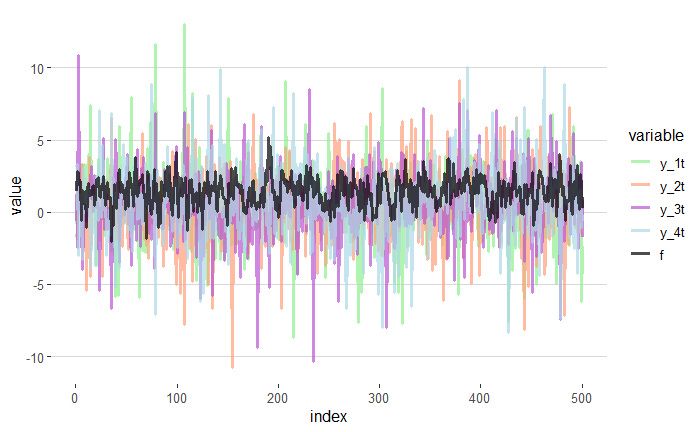

```r
f_graf <- melt(f[, c(7:11, 1)], id.vars = "index")
ggplot(f_graf, aes(x = index, y = value, color = variable))+
  geom_line(size=1.1, alpha=0.7)+
  scale_color_manual(values = c("Light Green", "lightsalmon", "mediumorchid", "Light Blue", "Black"))+
  theme_hc()+
  theme(legend.position = "right")
```

```r
#ggplot(f, aes(x = index, y = f))+
#  geom_line(size=1.1, alpha=0.7)+
#  scale_color_tableau("Tableau 10")+
#  theme_hc()+
#  theme(legend.position = "right")
```

.  
.  
.  
.  
.  
.  
.  
.  
.